# Flugverkehrsanalyse Schweiz (2016 - 2024)

```python
                    data_entry = {
                        'icao24': icao24_val, 'firstseen': firstseen_val, 'lastseen': lastseen_val,
                        'departure_airport': dep_airport_icao, 'arrival_airport': arr_airport_icao,
                        'callsign': callsign_val.strip().upper() if isinstance(callsign_val, str) else None,
                        'query_airport': query_airport_icao, 'flight_type': flight_type_val
                    }
                    if all([data_entry['icao24'], data_entry['firstseen'], data_entry['lastseen'], data_entry['query_airport']]) and data_entry['flight_type'] != 'Unknown':
                        processed_data_list.append(data_entry)
                except Exception as e:
                    logging.warning(f"Fehler bei der Verarbeitung Zeile für {query_airport_icao}: {e}. Zeile: {row_tuple}")
            return processed_data_list

        def get_flight_locality_os(row_series, swiss_airports_list):
            dep = str(row_series['departure_airport']).upper() if pd.notna(row_series['departure_airport']) else None
            arr = str(row_series['arrival_airport']).upper() if pd.notna(row_series['arrival_airport']) else None
            dep_is_swiss = pd.notna(dep) and dep in swiss_airports_list
            arr_is_swiss = pd.notna(arr) and arr in swiss_airports_list
            if dep_is_swiss and arr_is_swiss: return 'National'
            elif (dep_is_swiss and pd.notna(arr) and not arr_is_swiss) or \
                 (arr_is_swiss and pd.notna(dep) and not dep_is_swiss): return 'International'
            elif (dep_is_swiss and pd.isna(arr)) or (arr_is_swiss and pd.isna(dep)): return 'International (Unvollständig)'
            elif pd.notna(dep) and pd.notna(arr) and not dep_is_swiss and not arr_is_swiss: return 'Andere / Nicht-CH-Bezug'
            elif pd.isna(dep) and pd.isna(arr): return 'Unbekannt (Keine Route)'
            else: return 'Unbekannt (Sonstige)'

        # --- Hauptausführung der Datensammlung ---
        opensky_data_successfully_collected = False
        try:
            logging.info("Try Verbindung mit Trino herzustellen.")
            trino_conn = Trino()
            logging.info("Verbindung zu Trino erfolgreich hergestellt.")
            all_collected_flight_data = []
            for airport_code in OPENSKY_AIRPORTS_TO_QUERY:
                logging.info(f"--- Starte Datensammlung für Flughafen: {FLUGHAFEN_MAP.get(airport_code, airport_code)} ({airport_code}) ---")
                raw_df_airport = fetch_flight_data_os(trino_conn, airport_code, opensky_start_ts, opensky_stop_ts)
                if isinstance(raw_df_airport, pd.DataFrame) and not raw_df_airport.empty:
                    processed_list_airport = process_raw_data_os(raw_df_airport, airport_code)
                    if processed_list_airport:
                        all_collected_flight_data.extend(processed_list_airport)
                        logging.info(f"{len(processed_list_airport)} verarbeitete Datensätze für {airport_code} hinzugefügt.")
                else: logging.warning(f"Keine Daten für {airport_code} erhalten oder DataFrame war leer.")
                time.sleep(1)

            if not all_collected_flight_data:
                logging.warning("Keine validen Flugdaten über alle Flughäfen hinweg von OpenSky gesammelt.")
            else:
                df_opensky = pd.DataFrame(all_collected_flight_data)
                logging.info(f"Insgesamt {len(df_opensky)} Datensätze von OpenSky verarbeitet.")
                df_opensky['firstseen'] = pd.to_datetime(df_opensky['firstseen'], errors='coerce', utc=True)
                df_opensky['lastseen'] = pd.to_datetime(df_opensky['lastseen'], errors='coerce', utc=True)
                initial_rows_os = len(df_opensky)
                df_opensky.dropna(subset=['icao24', 'firstseen', 'lastseen', 'query_airport', 'flight_type'], inplace=True)
                logging.info(f"{initial_rows_os - len(df_opensky)} fehlerhafte Zeilen entfernt.")

                if df_opensky.empty:
                    logging.error("Nach Bereinigung sind keine Daten mehr vorhanden.")
                else:
                    subset_cols_dedup = ['icao24', 'firstseen', 'lastseen', 'departure_airport', 'arrival_airport']
                    initial_rows_before_dedup = len(df_opensky)
                    df_opensky.drop_duplicates(subset=subset_cols_dedup, keep='first', inplace=True)
                    logging.info(f"{initial_rows_before_dedup - len(df_opensky)} Duplikate entfernt.")

                    df_opensky['network_duration_minutes'] = (df_opensky['lastseen'] - df_opensky['firstseen']).dt.total_seconds() / 60
                    df_opensky.loc[df_opensky['network_duration_minutes'] < 0, 'network_duration_minutes'] = np.nan
                    df_opensky['airline_code'] = df_opensky['callsign'].astype(str).str[:3].str.upper()
                    df_opensky.loc[df_opensky['airline_code'].isin(['NON', 'NAN', '', 'N/A', 'UND', 'NULL']) | (df_opensky['airline_code'].str.len() < 3), 'airline_code'] = np.nan
                    df_opensky['locality'] = df_opensky.apply(get_flight_locality_os, args=(SCHWEIZER_FLUGHAFEN,), axis=1)
                    final_columns_os = ['icao24', 'firstseen', 'lastseen', 'query_airport', 'flight_type', 'callsign',
                                        'departure_airport', 'arrival_airport', 'network_duration_minutes',
                                        'airline_code', 'locality']
                    df_opensky = df_opensky[[col for col in final_columns_os if col in df_opensky.columns]]

                    df_save_os = df_opensky.copy()
                    df_save_os['firstseen'] = df_save_os['firstseen'].dt.strftime('%Y-%m-%d %H:%M:%S%z')
                    df_save_os['lastseen'] = df_save_os['lastseen'].dt.strftime('%Y-%m-%d %H:%M:%S%z')
                    df_save_os.to_csv(NEW_CSV_FILE_PATH, index=False, encoding='utf-8')
                    logging.info(f"Erfolgreich {len(df_save_os)} Datensätze in '{NEW_CSV_FILE_PATH}' gespeichert.")
                    CSV_DATEINAME = NEW_CSV_FILE_PATH # CSV-Datei aktualisieren!
                    logging.info(f"CSV_DATEINAME wurde auf '{CSV_DATEINAME}' aktualisiert.")
                    opensky_data_successfully_collected = True
        except Exception as e_main_os:
            logging.error(f"Fehler während OpenSky-Datensammlung: {e_main_os}")
        if not opensky_data_successfully_collected:
            logging.warning(f"OpenSky-Datensammlung nicht erfolgreich. Fallback auf: '{CSV_DATEINAME}'")
else:
    logging.info(f"EXECUTE_OPENSKY_LIVE_DATA_COLLECTION ist False. Überspringe Live-Datensammlung. Verwende: '{CSV_DATEINAME}'")
```

```python
logging.info(f"Datenquelle für Analyse: {CSV_DATEINAME}")
logging.info(f"Analysezeitraum: {ANALYSE_START_DATUM.date()} - {ANALYSE_ENDE_DATUM.date()}")
```

```
2025-05-20 18:03:31,166 - INFO - EXECUTE_OPENSKY_LIVE_DATA_COLLECTION ist False. Überspringe Live-Datensammlung. Verwende: 'data/swiss_flight_data_20160101_20241231.csv'
2025-05-20 18:03:31,167 - INFO - Datenquelle für Analyse: data/swiss_flight_data_20160101_20241231.csv
2025-05-20 18:03:31,167 - INFO - Analysezeitraum: 2016-01-01 - 2024-12-31
```

### 2.4 Laden der Rohdaten

Einlesen der Daten und erste Inspektion. Die Variable `CSV_DATEINAME` wurde möglicherweise im vorherigen optionalen Schritt (2.3.1) aktualisiert.

```python
logging.info(f"Lade Rohdaten aus {CSV_DATEINAME}...")
df_rohdaten = None
rohdaten_info = "" # Für Anhang
try:
    datums_columns = ['firstseen', 'lastseen']
    try:
        df_rohdaten = pd.read_csv(CSV_DATEINAME, parse_dates=datums_columns, sep=',', engine='python', on_bad_lines='warn')
    except (ValueError, pd.errors.ParserError): # Fallback auf Semikolon
        logging.warning("Komma als Trennzeichen fehlgeschlagen oder Parser-Fehler, versuche Semikolon.")
        df_rohdaten = pd.read_csv(CSV_DATEINAME, parse_dates=datums_columns, sep=';', engine='python', on_bad_lines='warn')
    # Fallback mit automatischer Erkennung von Trennzeichen
    except Exception as e_sep:
         logging.warning(f"Explizite Trennzeichenerkennung fehlgeschlagen ({e_sep}), versuche 'sep=None' für automatische Erkennung.")
         df_rohdaten = pd.read_csv(CSV_DATEINAME, parse_dates=datums_columns, sep=None, engine='python', on_bad_lines='warn')


    logging.info(f"{len(df_rohdaten)} Roh-Datensätze erfolgreich geladen.")
    logging.info(f"Columns: {list(df_rohdaten.columns)}")

    print("--- Erste 5 Zeilen der Rohdaten ---")
    display(df_rohdaten.head())
    print("\n--- Datentypen der Rohdaten ---")
    display(df_rohdaten.dtypes.to_frame('Datentyp'))

    buffer = io.StringIO()
    df_rohdaten.info(buf=buffer)
    rohdaten_info = buffer.getvalue() # Für Anhang
    print("\n--- Info zu Non-Null Counts und Speicherbedarf (Rohdaten) ---")
    print(rohdaten_info)

except FileNotFoundError:
    logging.error(f"Datei {CSV_DATEINAME} nicht gefunden.")
except pd.errors.EmptyDataError:
    logging.error(f"Datei {CSV_DATEINAME} ist leer.")
except Exception as e:
    logging.error(f"Fehler beim Laden der Datei '{CSV_DATEINAME}': {e}")
```

```
2025-05-20 18:03:31,208 - INFO - Lade Rohdaten aus data/swiss_flight_data_20160101_20241231.csv...
2025-05-20 18:03:50,789 - INFO - 2941854 Roh-Datensätze erfolgreich geladen.
2025-05-20 18:03:50,789 - INFO - Columns: ['icao24', 'firstseen', 'departure_airport', 'lastseen', 'arrival_airport', 'callsign', 'query_airport', 'flight_type', 'network_duration_minutes', 'airline_code', 'locality']
```

```
--- Erste 5 Zeilen der Rohdaten ---
```

|  | icao24 | firstseen | departure_airport | lastseen | arrival_airport | callsign | query_airport | flight_type | network_duration_minutes | airline_code | locality |
| --- | --- | --- | --- | --- | --- | --- | --- | --- | --- | --- | --- |
| 0 | 3c942d | 2016-03-03 09:17:57+00:00 | LSZH | 2016-03-03 09:27:59+00:00 | EDNY | DBEAM | LSZH | Departure | 10.033333 | DBE | International |
| 1 | 4b1613 | 2016-03-03 20:14:39+00:00 | LSZH | 2016-03-03 21:31:36+00:00 | EGLW | SWR24A | LSZH | Departure | 76.950000 | SWR | International |
| 2 | 4407da | 2016-03-03 18:10:16+00:00 | LSZH | 2016-03-03 19:00:56+00:00 | LOAV | NLY8611 | LSZH | Departure | 50.666667 | NLY | International |
| 3 | 400aff | 2016-03-03 19:14:16+00:00 | LSZH | 2016-03-03 20:36:55+00:00 | EGLW | BAW719 | LSZH | Departure | 82.650000 | BAW | International |
| 4 | 4407f3 | 2016-03-03 20:38:48+00:00 | LSZH | 2016-03-03 21:30:29+00:00 | LOAN | NLY115E | LSZH | Departure | 51.683333 | NLY | International |

```
--- Datentypen der Rohdaten ---
```

|  | Datentyp |
| --- | --- |
| icao24 | object |
| firstseen | datetime64[ns, UTC] |
| departure_airport | object |
| lastseen | datetime64[ns, UTC] |
| arrival_airport | object |
| callsign | object |
| query_airport | object |
| flight_type | object |
| network_duration_minutes | float64 |
| airline_code | object |
| locality | object |

```
--- Info zu Non-Null Counts und Speicherbedarf (Rohdaten) ---
<class 'pandas.core.frame.DataFrame'>
RangeIndex: 2941854 entries, 0 to 2941853
Data columns (total 11 columns):
 #   Column                    Dtype
---  ------                    -----
 0   icao24                    object
 1   firstseen                 datetime64[ns, UTC]
 2   departure_airport         object
 3   lastseen                  datetime64[ns, UTC]
 4   arrival_airport           object
 5   callsign                  object
 6   query_airport             object
 7   flight_type               object
 8   network_duration_minutes  float64
 9   airline_code              object
 10  locality                  object
dtypes: datetime64[ns, UTC](2), float64(1), object(8)
memory usage: 246.9+ MB
```

### 2.5 Datenbereinigung und -formatierung

Sicherstellung korrekter Datentypen, Behandlung fehlender Werte in kritischen Kollonen sowie Konsistenzprüfungen.

```python
df_cleaned = pd.DataFrame() # Initialisiere leeren DataFrame für den Fall, dass df_rohdaten None ist
bereinigt_info = "" # Für Anhang
bereinigt_describe = None # Für Anhang

if df_rohdaten is not None and not df_rohdaten.empty:
    logging.info("Beginne Datenbereinigung und -formatierung...")
    df_cleaned = df_rohdaten.copy()

    # --- Filtere Daten Analysezeitraum ---
    logging.info(f"Filtere Rohdaten auf den Zeitraum: {ANALYSE_START_DATUM.date()} bis {ANALYSE_ENDE_DATUM.date()}")
    # Sicherstellen, der Date-Formate
    for col_time_filter in ['firstseen', 'lastseen']:
        if col_time_filter in df_cleaned.columns:
            if not pd.api.types.is_datetime64_any_dtype(df_cleaned[col_time_filter]):
                df_cleaned[col_time_filter] = pd.to_datetime(df_cleaned[col_time_filter], errors='coerce')
            if pd.api.types.is_datetime64_any_dtype(df_cleaned[col_time_filter]):
                 if df_cleaned[col_time_filter].dt.tz is None:
                     df_cleaned[col_time_filter] = df_cleaned[col_time_filter].dt.tz_localize('UTC', ambiguous='NaT', nonexistent='NaT')
                 else:
                     df_cleaned[col_time_filter] = df_cleaned[col_time_filter].dt.tz_convert('UTC')
            else: # Falls Konvertierung Probleme macht
                logging.warning(f"Column {col_time_filter} konnte nicht in datetime konvertiert werden.")


    if 'firstseen' in df_cleaned.columns and pd.api.types.is_datetime64_any_dtype(df_cleaned['firstseen']):
        original_rows_before_date_filter = len(df_cleaned)
        df_cleaned = df_cleaned[
            (df_cleaned['firstseen'] >= ANALYSE_START_DATUM) &
            (df_cleaned['firstseen'] <= ANALYSE_ENDE_DATUM)
        ]
        rows_after_date_filter = len(df_cleaned)
        if original_rows_before_date_filter > rows_after_date_filter:
            logging.info(f"{original_rows_before_date_filter - rows_after_date_filter} Zeilen ausserhalb des gesetzten Analysezeitraums entfernt.")
        elif original_rows_before_date_filter == rows_after_date_filter and original_rows_before_date_filter > 0 :
             logging.info("Alle Daten sind innerhalb des Analysezeitraums.")
    else:
        logging.warning("Column 'firstseen' nicht im korrekten Datumsformat.")


    # --- UTC für firstseen und lastseen sicherstellen
    date_columns_clean = ['firstseen', 'lastseen']
    for column in date_columns_clean:
        if column in df_cleaned.columns:
            if not pd.api.types.is_datetime64_any_dtype(df_cleaned[column]):
                 df_cleaned[column] = pd.to_datetime(df_cleaned[column], errors='coerce') # errors='coerce' setzt ungültige Daten auf NaT

            if pd.api.types.is_datetime64_any_dtype(df_cleaned[column]):
                if df_cleaned[column].dt.tz is None:
                    try:
                        df_cleaned[column] = df_cleaned[column].dt.tz_localize('UTC', ambiguous='NaT', nonexistent='NaT')
                    except Exception as e_tz: # Falls Mehrdeutigkeit nicht mit NaT lösbar ist
                        logging.error(f"Fehler bei tz_localize für Column {column}: {e_tz}. Zeitstempel könnten inkonsistent sein.")
                        df_cleaned[column] = pd.to_datetime(df_cleaned[column], errors='coerce').dt.tz_localize(None).dt.tz_localize('UTC', ambiguous='NaT', nonexistent='NaT')
                elif str(df_cleaned[column].dt.tz) != 'UTC':
                    df_cleaned[column] = df_cleaned[column].dt.tz_convert('UTC')
            else:
                logging.warning(f"Column {column} konnte nicht in ein datetime-Format konvertiert werden. Use NaT.")
                df_cleaned[column] = pd.NaT
        else:
            logging.warning(f"Benötigte Zeit-Column {column} fehlt. Column wird mit pd.NaT erstellt.")
            df_cleaned[column] = pd.NaT


    # --- Schritt 2: Behandlung fehlender Werte (NaN/NaT) in wichtigen Columns ---
    necessary_columns = ['firstseen', 'lastseen', 'icao24', 'query_airport', 'flight_type']
    # Columns, welche NaN sein dürfen
    important_columns_features = ['callsign', 'departure_airport', 'arrival_airport']

    # Überprüfen, ob erforderliche Columns existieren
    missing_necc_columns_check = [s for s in necessary_columns if s not in df_cleaned.columns]
    if missing_necc_columns_check:
        logging.error(f"Essentielle Columns fehlen und können nicht verarbeitet werden: {', '.join(missing_necc_columns_check)}.")
        df_cleaned = pd.DataFrame() # Leeren, um weitere Fehler zu vermeiden
    else:
        # Entferne Zeilen, wo erforderliche Columns NaN/NaT sind
        initial_rows = len(df_cleaned)
        df_cleaned.dropna(subset=necessary_columns, inplace=True)
        rows_after_dropna = len(df_cleaned)
        if initial_rows > 0 and initial_rows > rows_after_dropna :
            logging.info(f"{initial_rows - rows_after_dropna} Zeilen ({ (initial_rows - rows_after_dropna) / initial_rows * 100:.1f}%) wegen fehlender Werte in kritischen Columns {necessary_columns} entfernt.")
        elif initial_rows == rows_after_dropna and initial_rows > 0:
             logging.info(f"Keine Zeilen aufgrund fehlender Werte in erforderlichen Columns {necessary_columns} entfernt.")

        # Überprüfe wichtige Feature-Columns
        for column in important_columns_features:
             if column not in df_cleaned.columns:
                 logging.warning(f"Wichtige Column '{column}' fehlt. Wird mit None hinzugefügt.")
                 df_cleaned[column] = None
             else: # Prüfe auf fehlende Werte
                 missing_count = df_cleaned[column].isnull().sum()
                 if missing_count > 0 and not df_cleaned.empty:
                      logging.warning(f"Feature-Column '{column}' hat {missing_count} fehlende Werte ({missing_count / len(df_cleaned) * 100:.1f}%).")


    # --- Schritt 3: Konsistenzprüfung der Zeitstempel ---
    if 'firstseen' in df_cleaned.columns and 'lastseen' in df_cleaned.columns and not df_cleaned.empty:
        # Sicherstellen, dass die Columns auch wirklich datetime sind nach allen Konvertierungen
        if pd.api.types.is_datetime64_any_dtype(df_cleaned['firstseen']) and \
           pd.api.types.is_datetime64_any_dtype(df_cleaned['lastseen']):
            invalid_time_order = df_cleaned['lastseen'] < df_cleaned['firstseen']
            if invalid_time_order.any():
                num_invalid = invalid_time_order.sum()
                logging.warning(f"{num_invalid} Zeilen ({num_invalid / len(df_cleaned) * 100:.1f}%) haben 'lastseen' vor 'firstseen'. Diese werden entfernt.")
                df_cleaned = df_cleaned[~invalid_time_order].copy()
        else:
            logging.warning("Zeit-Konsistenzprüfung übersprungen, da 'firstseen' oder 'lastseen' keine gültigen Datumsformate haben.")

    # --- Schritt 4: Normalisierung von Columns ---
    string_columns_to_normalize = ['callsign', 'query_airport', 'departure_airport', 'arrival_airport', 'flight_type', 'icao24']
    for col in string_columns_to_normalize:
        if col in df_cleaned.columns and df_cleaned[col].dtype == 'object': # Nur auf Objekt-Columns anwenden
            original_nulls = df_cleaned[col].isnull().sum()
            # In String umwandeln, Whitespace entfernen, Grossbuchstaben
            df_cleaned[col] = df_cleaned[col].astype(str).str.strip().str.upper()
            # Standard-NaN-ähnliche Strings zu echten NaNs konvertieren
            df_cleaned.loc[df_cleaned[col].isin(['', 'NAN', 'NONE', 'N/A', 'NULL', 'NA', '<NA>', 'UNDEFINED', 'UNDEF']), col] = np.nan
            new_nulls = df_cleaned[col].isnull().sum()
            if new_nulls > original_nulls:
                 logging.info(f"In Column '{col}' wurden {new_nulls - original_nulls} leere/ungültige Strings zu NaN konvertiert.")
        elif col in df_cleaned.columns and df_cleaned[col].isnull().all() and df_cleaned[col].dtype == 'object':
            df_cleaned[col] = np.nan
            logging.info(f"Column '{col}' (nur None-Werte) wurde zu NaN konvertiert.")

    if df_cleaned.empty:
        logging.error("DataFrame ist nach der Bereinigung leer. Abbruch der Analyse.")
    else:
        logging.info(f"Datenbereinigung abgeschlossen. Verbleibende Datensätze: {len(df_cleaned)}")
        print("\n--- Erste 5 Zeilen nach Bereinigung ---");
        display(df_cleaned.head())
        print("\n--- Datentypen nach Bereinigung ---");
        display(df_cleaned.dtypes.to_frame('Datentyp'))

        buffer_info_b = io.StringIO()
        df_cleaned.info(buf=buffer_info_b)
        bereinigt_info = buffer_info_b.getvalue() # Für Anhang
        print("\n--- Info zu Non-Null Counts und Speicherbedarf (Bereinigt) ---");
        print(bereinigt_info)
        print("\n--- Deskriptive Statistik für numerische Columns (Bereinigt) ---")
        bereinigt_describe = df_cleaned.describe(include=np.number) # Für Anhang
        display(bereinigt_describe.style.format('{:.2f}'))
else:
    logging.error("Laden der Rohdaten fehlgeschlagen oder DataFrame war leer. Überspringe Bereinigung.")
    df_cleaned = pd.DataFrame()
```

```
2025-05-20 18:03:50,981 - INFO - Beginne Datenbereinigung und -formatierung...
2025-05-20 18:03:51,049 - INFO - Filtere Rohdaten auf den Zeitraum: 2016-01-01 bis 2024-12-31
2025-05-20 18:03:51,217 - INFO - 775 Zeilen ausserhalb des gesetzten Analysezeitraums entfernt.
2025-05-20 18:03:51,509 - INFO - Keine Zeilen aufgrund fehlender Werte in erforderlichen Columns ['firstseen', 'lastseen', 'icao24', 'query_airport', 'flight_type'] entfernt.
2025-05-20 18:03:51,571 - WARNING - Feature-Column 'callsign' hat 7036 fehlende Werte (0.2%).
2025-05-20 18:03:51,614 - WARNING - Feature-Column 'departure_airport' hat 63707 fehlende Werte (2.2%).
2025-05-20 18:03:54,894 - INFO - Datenbereinigung abgeschlossen. Verbleibende Datensätze: 2941079
```

```
--- Erste 5 Zeilen nach Bereinigung ---
```

|  | icao24 | firstseen | departure_airport | lastseen | arrival_airport | callsign | query_airport | flight_type | network_duration_minutes | airline_code | locality |
| --- | --- | --- | --- | --- | --- | --- | --- | --- | --- | --- | --- |
| 0 | 3C942D | 2016-03-03 09:17:57+00:00 | LSZH | 2016-03-03 09:27:59+00:00 | EDNY | DBEAM | LSZH | DEPARTURE | 10.033333 | DBE | International |
| 1 | 4B1613 | 2016-03-03 20:14:39+00:00 | LSZH | 2016-03-03 21:31:36+00:00 | EGLW | SWR24A | LSZH | DEPARTURE | 76.950000 | SWR | International |
| 2 | 4407DA | 2016-03-03 18:10:16+00:00 | LSZH | 2016-03-03 19:00:56+00:00 | LOAV | NLY8611 | LSZH | DEPARTURE | 50.666667 | NLY | International |
| 3 | 400AFF | 2016-03-03 19:14:16+00:00 | LSZH | 2016-03-03 20:36:55+00:00 | EGLW | BAW719 | LSZH | DEPARTURE | 82.650000 | BAW | International |
| 4 | 4407F3 | 2016-03-03 20:38:48+00:00 | LSZH | 2016-03-03 21:30:29+00:00 | LOAN | NLY115E | LSZH | DEPARTURE | 51.683333 | NLY | International |

```
--- Datentypen nach Bereinigung ---
```

|  | Datentyp |
| --- | --- |
| icao24 | object |
| firstseen | datetime64[ns, UTC] |
| departure_airport | object |
| lastseen | datetime64[ns, UTC] |
| arrival_airport | object |
| callsign | object |
| query_airport | object |
| flight_type | object |
| network_duration_minutes | float64 |
| airline_code | object |
| locality | object |

```
--- Info zu Non-Null Counts und Speicherbedarf (Bereinigt) ---
<class 'pandas.core.frame.DataFrame'>
Index: 2941079 entries, 0 to 2941853
Data columns (total 11 columns):
 #   Column                    Dtype
---  ------                    -----
 0   icao24                    object
 1   firstseen                 datetime64[ns, UTC]
 2   departure_airport         object
 3   lastseen                  datetime64[ns, UTC]
 4   arrival_airport           object
 5   callsign                  object
 6   query_airport             object
 7   flight_type               object
 8   network_duration_minutes  float64
 9   airline_code              object
 10  locality                  object
dtypes: datetime64[ns, UTC](2), float64(1), object(8)
memory usage: 269.3+ MB


--- Deskriptive Statistik für numerische Columns (Bereinigt) ---
```

|  | network_duration_minutes |
| --- | --- |
| count | 2941079.00 |
| mean | 108.39 |
| std | 129.10 |
| min | 10.02 |
| 25% | 52.98 |
| 50% | 73.13 |
| 75% | 107.08 |
| max | 2532.52 |

### 2.6 Feature Engineering

Erstellung neuer, für die Analyse relevanter Columns basierend auf den bereinigten Daten.

```python
if not df_cleaned.empty:
    logging.info("Start Feature Engineering.")
    df_final = df_cleaned.copy() # Arbeite mit einer Kopie des bereinigten DataFrames

    # --- 1. Netzwerksichtbarkeitsdauer ---
    duration_col = 'network_duration_minutes'
    # Sicherstellen, dass Columns existieren und im korrekten Format sind
    if 'firstseen' in df_final.columns and 'lastseen' in df_final.columns and \
       pd.api.types.is_datetime64_any_dtype(df_final['firstseen']) and \
       pd.api.types.is_datetime64_any_dtype(df_final['lastseen']):

        # Überprüfen auf konsistente Zeitzonen
        tz_first = df_final['firstseen'].dt.tz
        tz_last = df_final['lastseen'].dt.tz

        if (tz_first is not None and tz_last is not None and str(tz_first) == str(tz_last)) or \
           (tz_first is None and tz_last is None): # Falls beide naiv sind (sollte nicht passieren)
            time_diff = df_final['lastseen'] - df_final['firstseen']
            df_final[duration_col] = time_diff.dt.total_seconds() / 60

            # Behandlung von ungültigen Dauern
            min_plausible_duration = 0.1
            invalid_duration_mask = (df_final[duration_col] < min_plausible_duration) | (df_final[duration_col].isnull())
            num_invalid_before_set_nan = invalid_duration_mask.sum()

            df_final.loc[invalid_duration_mask, duration_col] = np.nan # Setze ungültige auf NaN
            num_invalid_after_set_nan = df_final[duration_col].isnull().sum()

            if num_invalid_after_set_nan > (num_invalid_before_set_nan - df_final[duration_col].isnull().sum()): # Logge nur, wenn neue NaNs gesetzt wurden
                 logging.warning(f"{num_invalid_after_set_nan - (num_invalid_before_set_nan - df_final[duration_col].isnull().sum())} Flüge hatten eine Dauer < {min_plausible_duration} Min und wurden auf NaN gesetzt.")

            valid_duration_count = df_final[duration_col].notna().sum()
            logging.info(f"'{duration_col}' berechnet. {valid_duration_count} gültige Werte ({valid_duration_count / len(df_final) * 100:.1f}%).")
        else:
             logging.error(f"Zeitzonen von 'firstseen' ({tz_first}) und 'lastseen' ({tz_last}) sind inkonsistent. '{duration_col}' wird auf NaN gesetzt.")
             df_final[duration_col] = np.nan
    else:
        logging.error(f"'{duration_col}' konnte nicht berechnet werden, da 'firstseen'/'lastseen' fehlen oder ungültiges Format haben. Column wird mit NaN gefüllt.")
        df_final[duration_col] = np.nan

    # --- 2. Airline Code ---
    airline_col = 'airline_code'
    if 'callsign' in df_final.columns:
        # Sicherstellen, dass 'callsign' ein String ist und nicht NaN
        df_final['callsign'] = df_final['callsign'].astype(str)
        # Bedingung für gültige Airline-Codes: nicht NaN, Länge >= 3, die ersten 3 Zeichen sind keine Zahlen und nicht generische Platzhalter
        condition = (
            df_final['callsign'].notna() &
            (df_final['callsign'].str.len() >= 3) &
            (~df_final['callsign'].str[:3].str.contains(r'\d', na=False)) & # Keine Ziffern in den ersten 3 Chars
            (~df_final['callsign'].str[:3].isin(['NON', 'NAN', 'N/A', 'UNK', 'UND', 'NONE', 'NULL']))
        )
        df_final[airline_col] = df_final['callsign'].str[:3].str.upper().where(condition, np.nan) # Ansonsten NaN

        valid_airline_count = df_final[airline_col].notna().sum()
        logging.info(f"'{airline_col}' (Approximation aus 'callsign') extrahiert. {valid_airline_count} gültige Codes ({valid_airline_count / len(df_final) * 100:.1f}%).")
    else:
        logging.warning(f"Column 'callsign' fehlt. '{airline_col}' kann nicht extrahiert werden. Column wird NaN gesetzt.")
        df_final[airline_col] = np.nan


    # --- 3. Fluglokalität (National/International) ---
    locality_col = 'locality'
    if 'departure_airport' in df_final.columns and 'arrival_airport' in df_final.columns:

        def determine_flight_locality(row):
            dep = row['departure_airport']
            arr = row['arrival_airport']

            dep_is_valid_str = isinstance(dep, str) and pd.notna(dep)
            arr_is_valid_str = isinstance(arr, str) and pd.notna(arr)
            dep_is_swiss = dep_is_valid_str and dep in SCHWEIZER_FLUGHAFEN
            arr_is_swiss = arr_is_valid_str and arr in SCHWEIZER_FLUGHAFEN

            if dep_is_swiss and arr_is_swiss: return 'National'
            elif (dep_is_swiss and arr_is_valid_str and not arr_is_swiss) or \
                 (arr_is_swiss and dep_is_valid_str and not dep_is_swiss): return 'International'
            # Fälle, wo ein Flughafen CH ist, der andere aber NaN (unvollständig)
            elif (dep_is_swiss and not arr_is_valid_str) or \
                 (arr_is_swiss and not dep_is_valid_str): return 'International (Unvollständig)'
            # Fälle, wo beide Flughäfen bekannt, aber keiner davon CH ist (z.B. Überflug, sollte durch query_airport nicht vorkommen)
            elif dep_is_valid_str and arr_is_valid_str and not dep_is_swiss and not arr_is_swiss: return 'Andere / Nicht-CH-Bezug'
            # Fälle, wo beide Flughäfen NaN sind
            elif not dep_is_valid_str and not arr_is_valid_str: return 'Unbekannt (Keine Route)'
            # Alle anderen denkbaren Kombinationen
            else: return 'Unbekannt (Sonstige)'

        df_final[locality_col] = df_final.apply(determine_flight_locality, axis=1)
        logging.info(f"'{locality_col}' (National/International/Andere) berechnet. Verteilung (Top 5):\n{df_final[locality_col].value_counts(normalize=True, dropna=False).round(3).head()}")
    else:
        logging.warning(f"Columns 'departure_airport' oder 'arrival_airport' fehlen. '{locality_col}' kann nicht berechnet werden. Column wird mit 'Unbekannt (Fehlende Columns)' gefüllt.")
        df_final[locality_col] = 'Unbekannt (Fehlende Columns)'


    # --- 4. Zeitliche Merkmale (Jahr, Monat, Wochentag) ---
    time_features_generated = False
    if 'firstseen' in df_final.columns and pd.api.types.is_datetime64_any_dtype(df_final['firstseen']):
         # Nur extrahieren, wenn es mindestens einen gültigen (nicht NaT) Zeitstempel gibt
         if df_final['firstseen'].notna().any():
             df_final['jahr'] = df_final['firstseen'].dt.year.astype('Int64') # Nullable Integer
             df_final['monat_nr'] = df_final['firstseen'].dt.month.astype('Int64')
             df_final['monat_name'] = df_final['firstseen'].dt.month_name()
             df_final['wochentag_nr'] = df_final['firstseen'].dt.dayofweek.astype('Int64') # Monday=0, Sunday=6
             df_final['wochentag_name'] = df_final['firstseen'].dt.day_name()
             df_final['stunde'] = df_final['firstseen'].dt.hour.astype('Int64') # Stunde des Tages
             df_final['quartal'] = df_final['firstseen'].dt.quarter.astype('Int64') # Quartal

             logging.info("Zeitliche Features ('jahr', 'monat_nr/name', 'wochentag_nr/name', 'stunde', 'quartal') extrahiert.")
             time_features_generated = True
         else:
             logging.warning("Column 'firstseen' enthält nur NaT-Werte. Wird NaN gesetzt.")
    else:
         logging.warning("Column 'firstseen' ungültig oder fehlt für Extraktion zeitlicher Features. Wird NaN gesetzt.")

    if not time_features_generated: # Wenn Features nicht generiert werden können
        for col_tf in ['jahr', 'monat_nr', 'monat_name', 'wochentag_nr', 'wochentag_name', 'stunde', 'quartal']:
            df_final[col_tf] = pd.NA if col_tf in ['jahr', 'monat_nr', 'wochentag_nr', 'stunde', 'quartal'] else None


    final_columns = list(df_final.columns)
    logging.info(f"Feature Engineering abgeschlossen. Finale Columns: {final_columns}")
    print("\n--- Inspektion der Daten nach Feature Engineering (Erste 5 Zeilen) ---");
    display(df_final.head())
    print("\n--- Datentypen ---");
    display(df_final.dtypes.to_frame('Datentyp'))

    # Info und Describe für den Anhang
    buffer_info_final = io.StringIO()
    df_final.info(buf=buffer_info_final)
    final_info = buffer_info_final.getvalue() # Für Anhang
    final_describe = df_final.describe(include='all') # Für Anhang
else:
    logging.error("Bereinigter DataFrame ist leer.")
    df_final = pd.DataFrame()
```

[output not shown]

```
--- Inspektion der Daten nach Feature Engineering (Erste 5 Zeilen) ---
```

|  | icao24 | firstseen | departure_airport | lastseen | arrival_airport | callsign | query_airport | flight_type | network_duration_minutes | airline_code | locality | jahr | monat_nr | monat_name | wochentag_nr | wochentag_name | stunde | quartal |
| --- | --- | --- | --- | --- | --- | --- | --- | --- | --- | --- | --- | --- | --- | --- | --- | --- | --- | --- |
| 0 | 3C942D | 2016-03-03 09:17:57+00:00 | LSZH | 2016-03-03 09:27:59+00:00 | EDNY | DBEAM | LSZH | DEPARTURE | 10.033333 | DBE | International | 2016 | 3 | March | 3 | Thursday | 9 | 1 |
| 1 | 4B1613 | 2016-03-03 20:14:39+00:00 | LSZH | 2016-03-03 21:31:36+00:00 | EGLW | SWR24A | LSZH | DEPARTURE | 76.950000 | SWR | International | 2016 | 3 | March | 3 | Thursday | 20 | 1 |
| 2 | 4407DA | 2016-03-03 18:10:16+00:00 | LSZH | 2016-03-03 19:00:56+00:00 | LOAV | NLY8611 | LSZH | DEPARTURE | 50.666667 | NLY | International | 2016 | 3 | March | 3 | Thursday | 18 | 1 |
| 3 | 400AFF | 2016-03-03 19:14:16+00:00 | LSZH | 2016-03-03 20:36:55+00:00 | EGLW | BAW719 | LSZH | DEPARTURE | 82.650000 | BAW | International | 2016 | 3 | March | 3 | Thursday | 19 | 1 |
| 4 | 4407F3 | 2016-03-03 20:38:48+00:00 | LSZH | 2016-03-03 21:30:29+00:00 | LOAN | NLY115E | LSZH | DEPARTURE | 51.683333 | NLY | International | 2016 | 3 | March | 3 | Thursday | 20 | 1 |

```
--- Datentypen ---
```

|  | Datentyp |
| --- | --- |
| icao24 | object |
| firstseen | datetime64[ns, UTC] |
| departure_airport | object |
| lastseen | datetime64[ns, UTC] |
| arrival_airport | object |
| callsign | object |
| query_airport | object |
| flight_type | object |
| network_duration_minutes | float64 |
| airline_code | object |
| locality | object |
| jahr | Int64 |
| monat_nr | Int64 |
| monat_name | object |
| wochentag_nr | Int64 |
| wochentag_name | object |
| stunde | Int64 |
| quartal | Int64 |

## 3. Schritt: Analyse der Daten (Analyze Data)

**Ziel:** Anwendung primär deskriptiver statistischer Methoden sowie exemplarisch **prädiktiver Verfahren** auf die vorbereiteten Daten (`df_final`), um Muster, Trends und mögliche zukünftige Entwicklungen zu identifizieren und die KAQs aus Schritt 1 zu beantworten (Marr, 2020).

**Hinweis:** Die tiefere Interpretation und Synthese zu handlungsrelevanten Insights erfolgt in Schritt 5.

### 3.1 KAQ 1: Entwicklung und Verteilung des gesamten Flugverkehrsaufkommens

```python
beobachtungen_dict = {}

if not df_final.empty and 'query_airport' in df_final.columns:
    start_year_data = df_final['jahr'].min() if 'jahr' in df_final.columns and df_final['jahr'].notna().any() else "N/A"
    end_year_data = df_final['jahr'].max() if 'jahr' in df_final.columns and df_final['jahr'].notna().any() else "N/A"

    total_flights_final = len(df_final)
    print(f"**Gesamtzahl analysierter Flugdatensätze (nach Bereinigung & FE, {start_year_data}-{end_year_data}): {total_flights_final:,}**\n")
    print(f"--- Beobachtung: Verkehrsaufkommen pro abgefragtem Flughafen (Gesamtzeitraum {start_year_data}-{end_year_data}) ---")
    # Filtere auf zu analysierende Flughäfen
    relevant_airports_in_data = [ap for ap in FLUGHAFEN_ZU_ANALYSIEREN if ap in df_final['query_airport'].unique()]

    if relevant_airports_in_data:
        airport_counts = df_final[df_final['query_airport'].isin(relevant_airports_in_data)]['query_airport'] \
                            .value_counts().to_frame('Anzahl Flüge')
        if not airport_counts.empty:
            total_analyzed_flights_in_scope = airport_counts['Anzahl Flüge'].sum()
            if total_analyzed_flights_in_scope > 0:
                airport_counts['Anteil (%)'] = (airport_counts['Anzahl Flüge'] / total_analyzed_flights_in_scope * 100).round(1)
            else:
                airport_counts['Anteil (%)'] = 0.0

            airport_counts.index.name = "Flughafen (ICAO)"
            # Füge Komplettnamen für Flughafen hinzu
            airport_counts['Flughafen Name'] = airport_counts.index.map(FLUGHAFEN_MAP)
            airport_counts = airport_counts[['Flughafen Name', 'Anzahl Flüge', 'Anteil (%)']] # Columnsreihenfolge
            # Gesamt Analysiert
            airport_counts.loc['Gesamt Analysiert'] = airport_counts.sum(numeric_only=True)
            # Prozentanteil für Gesamt korrigieren (Summe der Einzelanteile)
            if total_analyzed_flights_in_scope > 0 :
                sum_of_percentages = airport_counts['Anteil (%)'][:-1].sum()
                clipped_sum = np.clip(sum_of_percentages, None, 100.0)
                rounded_clipped_sum = np.round(clipped_sum,1)
                airport_counts.loc['Gesamt Analysiert', 'Anteil (%)'] = rounded_clipped_sum
            else:
                 airport_counts.loc['Gesamt Analysiert', 'Anteil (%)'] = 0.0

            airport_counts.loc['Gesamt Analysiert', 'Flughafen Name'] = 'Gesamt Analysiert'

            display(airport_counts.style.format({'Anzahl Flüge': '{:,.0f}', 'Anteil (%)': '{:.1f}%'}))

            if not airport_counts.drop('Gesamt Analysiert', errors='ignore').empty:
                top_airport_icao = airport_counts.drop('Gesamt Analysiert', errors='ignore').index[0]
                top_airport_name = airport_counts.loc[top_airport_icao, 'Flughafen Name']
                top_share = airport_counts.loc[top_airport_icao, 'Anteil (%)']
                top_count = airport_counts.loc[top_airport_icao, 'Anzahl Flüge']
                beobachtung_kaq1_text = f"{top_airport_name} ({top_airport_icao}) war der verkehrsreichste der analysierten Flughäfen mit {top_count:,.0f} Flügen ({top_share:.1f}% des Volumens der analysierten Flughäfen)."
                print(f"\nBeobachtung KAQ1 (Verteilung): {beobachtung_kaq1_text}")
                beobachtungen_dict['KAQ1_Verteilung'] = beobachtung_kaq1_text
            else:
                print("Keine Daten für die zu analysierenden Flughäfen in den Top-Counts gefunden.")

        else:
            print("Keine Daten für die zu analysierenden Flughäfen gefunden, um Verkehrsaufkommen zu zählen.")
    else:
        logging.warning("Keiner der zu analysierenden Flughäfen (FLUGHAFEN_ZU_ANALYSIEREN) wurde in der Column 'query_airport' des finalen DataFrames gefunden.")
        print("Keine der zu analysierenden Flughäfen im Datensatz gefunden.")

else:
    logging.warning("KAQ1 Analyse (Verkehrsaufkommen) übersprungen.")
    print("KAQ1 Analyse übersprungen: Keine Daten.")
```

```
**Gesamtzahl analysierter Flugdatensätze (nach Bereinigung & FE, 2016-2024): 2,941,079**

--- Beobachtung: Verkehrsaufkommen pro abgefragtem Flughafen (Gesamtzeitraum 2016-2024) ---
```

| Flughafen (ICAO) | Flughafen Name | Anzahl Flüge | Anteil (%) |
| --- | --- | --- | --- |
| LSZH | Zürich | 1,390,722 | 47.3% |
| LSGG | Genève | 896,594 | 30.5% |
| LFSB | Basel-Mulhouse (EuroAirport) | 486,786 | 16.6% |
| LSZB | Bern-Belp | 79,872 | 2.7% |
| LSZR | St. Gallen-Altenrhein | 52,787 | 1.8% |
| LSZA | Lugano-Agno | 34,318 | 1.2% |
| Gesamt Analysiert | Gesamt Analysiert | 2,941,079 | 100.0% |

```
Beobachtung KAQ1 (Verteilung): Zürich (LSZH) war der verkehrsreichste der analysierten Flughäfen mit 1,390,722 Flügen (47.3% des Volumens der analysierten Flughäfen).
```

### 3.2 Zeitliche Entwicklung (Jährlich und Monatlich) am Beispiel des Flughafens Zürich

```
--- Beobachtung: Jährlicher Verkehrstrend für Zürich (LSZH) ---
```

| jahr | Anzahl Flüge | Vorjahresveränderung (%) |
| --- | --- | --- |
| 2016 | 72,330 | +nan% |
| 2017 | 158,396 | +119.0% |
| 2018 | 176,286 | +11.3% |
| 2019 | 204,531 | +16.0% |
| 2020 | 89,176 | -56.4% |
| 2021 | 98,924 | +10.9% |
| 2022 | 175,673 | +77.6% |
| 2023 | 200,386 | +14.1% |
| 2024 | 215,020 | +7.3% |

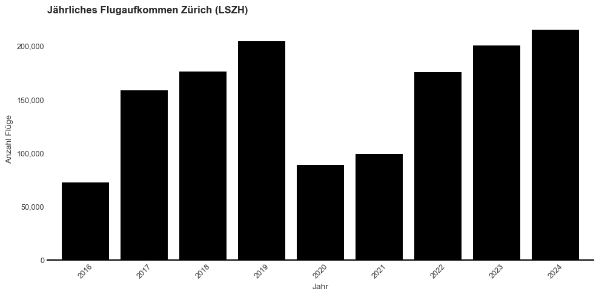

```
Beobachtung KAQ1 (Trend Zürich): Am Zürich erreichte das Aufkommen 2024 mit 215,020 Flügen seinen Höhepunkt und 2016 mit 72,330 seinen Tiefpunkt im Analysezeitraum.

--- Beobachtung: Monatlicher Verkehrstrend für Zürich (Jahre: 2023, 2024) ---
```

| Monat | Anzahl Flüge |
| --- | --- |
| 2023-01 (January) | 13,414 |
| 2023-02 (February) | 13,501 |
| 2023-03 (March) | 16,061 |
| 2023-04 (April) | 16,994 |
| 2023-05 (May) | 18,560 |
| 2023-06 (June) | 18,260 |
| 2023-07 (July) | 19,091 |
| 2023-08 (August) | 19,155 |
| 2023-09 (September) | 19,385 |
| 2023-10 (October) | 15,583 |
| 2023-11 (November) | 15,730 |
| 2023-12 (December) | 14,652 |
| 2024-01 (January) | 15,988 |
| 2024-02 (February) | 15,551 |
| 2024-03 (March) | 16,859 |
| 2024-04 (April) | 17,936 |
| 2024-05 (May) | 18,100 |
| 2024-06 (June) | 18,345 |
| 2024-07 (July) | 20,076 |
| 2024-08 (August) | 20,291 |
| 2024-09 (September) | 20,146 |
| 2024-10 (October) | 18,572 |
| 2024-11 (November) | 16,900 |
| 2024-12 (December) | 16,256 |

```python
if not df_final.empty and 'firstseen' in df_final.columns and \
   'query_airport' in df_final.columns and 'jahr' in df_final.columns and \
   FLUGHAFEN_ZU_ANALYSIEREN and 'airport_counts' in locals() and not airport_counts.drop('Gesamt Analysiert', errors='ignore').empty :

    # Bestimme den Primärflughafen aus der vorherigen Analyse (airport_counts)
    valid_airport_counts = airport_counts.drop('Gesamt Analysiert', errors='ignore')
    if not valid_airport_counts.empty:
        target_airport_trend_icao = valid_airport_counts.index[0] # ICAO des verkehrsreichsten Flughafens
        target_airport_trend_name = valid_airport_counts.iloc[0]['Flughafen Name']
        print(f"--- Beobachtung: Jährlicher Verkehrstrend für {target_airport_trend_name} ({target_airport_trend_icao}) ---")

        # Filtere Daten für den Ziel-Flughafen
        df_target_airport = df_final[df_final['query_airport'] == target_airport_trend_icao].copy()

        if not df_target_airport.empty and pd.api.types.is_numeric_dtype(df_target_airport['jahr']) and df_target_airport['jahr'].notna().any():
            yearly_counts = df_target_airport.groupby('jahr').size().to_frame('Anzahl Flüge')
            # Sicherstellen, dass der Index sortiert ist für korrekte pct_change Berechnung
            yearly_counts.sort_index(inplace=True)

            if not yearly_counts.empty:
                yearly_counts['Vorjahresveränderung (%)'] = yearly_counts['Anzahl Flüge'].pct_change() * 100
                display(yearly_counts.style.format({'Anzahl Flüge': '{:,.0f}', 'Vorjahresveränderung (%)': '{:+.1f}%'}))

                # Plot für jährliche Entwicklung
                fig_yearly, ax_yearly = plt.subplots(figsize=(10, 5)) # Etwas breiter für mehr Jahre
                yearly_counts['Anzahl Flüge'].plot(kind='bar', ax=ax_yearly, color=IBCS_SCHWARZ, legend=None, width=0.8)
                ax_yearly.set_title(f'Jährliches Flugaufkommen {target_airport_trend_name} ({target_airport_trend_icao})', fontsize=12, fontweight='bold', loc='left')
                ax_yearly.set_xlabel('Jahr', fontsize=10)
                ax_yearly.set_ylabel('Anzahl Flüge', fontsize=10)
                ax_yearly.yaxis.set_major_formatter(mtick.FuncFormatter(lambda x, _: '{:,.0f}'.format(x)))
                ax_yearly.tick_params(axis='x', rotation=45, labelsize=9)
                ax_yearly.tick_params(axis='y', labelsize=9)
                # IBCS: Achsen hervorheben
                ax_yearly.spines['bottom'].set_color(IBCS_SCHWARZ)
                ax_yearly.spines['bottom'].set_linewidth(1.5)

                plt.tight_layout()
                plt.show()

                # Beobachtung für Management Summary
                peak_year = yearly_counts['Anzahl Flüge'].idxmax()
                peak_flights = yearly_counts['Anzahl Flüge'].max()
                trough_year = yearly_counts['Anzahl Flüge'].idxmin() # Tiefpunkt
                trough_flights = yearly_counts['Anzahl Flüge'].min()
                beobachtung_kaq1_trend_text = f"Am {target_airport_trend_name} erreichte das Aufkommen {peak_year} mit {peak_flights:,.0f} Flügen seinen Höhepunkt und {trough_year} mit {trough_flights:,.0f} seinen Tiefpunkt im Analysezeitraum."
                print(f"Beobachtung KAQ1 (Trend {target_airport_trend_name}): {beobachtung_kaq1_trend_text}")
                beobachtungen_dict[f'KAQ1_Trend_{target_airport_trend_icao}'] = beobachtung_kaq1_trend_text
            else:
                print(f"Keine jährlichen Daten für {target_airport_trend_name} gefunden.")

            # Monatliche Entwicklung für die letzten zwei Jahre im Datensatz
            available_years = sorted(df_target_airport['jahr'].dropna().unique().astype(int))
            if len(available_years) >= 2:
                last_two_full_years = available_years[-2:]
                print(f"\n--- Beobachtung: Monatlicher Verkehrstrend für {target_airport_trend_name} (Jahre: {', '.join(map(str, last_two_full_years))}) ---")
                df_target_last_years = df_target_airport[df_target_airport['jahr'].isin(last_two_full_years)].copy()

                if not df_target_last_years.empty and \
                   pd.api.types.is_datetime64_any_dtype(df_target_last_years['firstseen']) and \
                   df_target_last_years['firstseen'].notna().any():

                    # Resample erfordert einen DatetimeIndex
                    df_target_last_years.set_index('firstseen', inplace=True)
                    # 'ME' für Monatsende (Month End frequency)
                    monthly_counts_detail = df_target_last_years.resample('ME').size().to_frame('Anzahl Flüge')

                    if not monthly_counts_detail.empty:
                        # Index für bessere Lesbarkeit formatieren
                        monthly_counts_detail.index = monthly_counts_detail.index.strftime('%Y-%m (%B)')
                        monthly_counts_detail.index.name = 'Monat'
                        display(monthly_counts_detail.style.format({'Anzahl Flüge': '{:,.0f}'}))
                    else:
                        print(f"Keine monatlichen Daten für die Jahre {', '.join(map(str, last_two_full_years))} für {target_airport_trend_name} gefunden.")
                else:
                    print(f"Keine ausreichenden Daten für monatlichen Trend der Jahre {', '.join(map(str, last_two_full_years))} ({target_airport_trend_name}).")
            elif len(available_years) == 1:
                 print(f"\nNur ein Jahr ({available_years[0]}) im Datensatz für {target_airport_trend_name} vorhanden. Zeige monatlichen Trend für dieses Jahr.")
                 df_target_one_year = df_target_airport[df_target_airport['jahr'] == available_years[0]].copy()
                 if not df_target_one_year.empty and pd.api.types.is_datetime64_any_dtype(df_target_one_year['firstseen']) and df_target_one_year['firstseen'].notna().any():
                    df_target_one_year.set_index('firstseen', inplace=True)
                    monthly_counts_one_year = df_target_one_year.resample('ME').size().to_frame('Anzahl Flüge')
                    if not monthly_counts_one_year.empty:
                        monthly_counts_one_year.index = monthly_counts_one_year.index.strftime('%Y-%m (%B)')
                        monthly_counts_one_year.index.name = 'Monat'
                        display(monthly_counts_one_year.style.format({'Anzahl Flüge': '{:,.0f}'}))
                    else: print(f"Keine monatlichen Daten für {available_years[0]} gefunden.")
                 else: print(f"Keine ausreichenden Daten für monatlichen Trend ({available_years[0]}) für {target_airport_trend_name}.")

            else:
                print(f"Nicht genügend Jahre im Datensatz für {target_airport_trend_name}, um monatliche Trends anzuzeigen.")
        else:
            print(f"Keine ausreichenden Daten ('jahr' Column fehlt oder ist leer) für jährliche Trendanalyse von {target_airport_trend_name}.")
    else:
        print(f"Primärflughafen für Trendanalyse konnte nicht bestimmt werden (airport_counts ist leer nach Filterung).")
else:
    print("Überspringe zeitliche Trendanalyse: Fehlende Daten, Konfiguration oder `airport_counts` nicht verfügbar.")
```

### 3.3 KAQ 2: Aktivität der Fluggesellschaften

(Code aus vorheriger Version für 3.3, angepasst an `df_final`)

```python
airline_col_kaq2 = 'airline_code'
start_year_data_kaq2 = df_final['jahr'].min() if 'jahr' in df_final.columns and df_final['jahr'].notna().any() else "N/A"
end_year_data_kaq2 = df_final['jahr'].max() if 'jahr' in df_final.columns and df_final['jahr'].notna().any() else "N/A"


if not df_final.empty and airline_col_kaq2 in df_final.columns:
    print(f"\n--- Beobachtung: Top 15 Airline-Codes (Gesamter Schweizer Luftraum der Analyse, Approximation, {start_year_data_kaq2}-{end_year_data_kaq2}) ---")
    # Betrachte nur Flüge, die einen Bezug zu den SCHWEIZER_FLUGHAFEN haben, um konsistent zu sein
    df_swiss_related_flights = df_final[df_final['query_airport'].isin(SCHWEIZER_FLUGHAFEN)]
    df_valid_airlines_overall = df_swiss_related_flights.dropna(subset=[airline_col_kaq2])

    if not df_valid_airlines_overall.empty:
        top_airlines_gesamt = df_valid_airlines_overall[airline_col_kaq2].value_counts().head(15).to_frame('Anzahl Flüge')
        total_valid_airline_flights_overall = len(df_valid_airlines_overall) # Gesamtzahl der Flüge mit gültigem Airline-Code

        if total_valid_airline_flights_overall > 0:
            top_airlines_gesamt['Anteil an Flügen mit Airline-Code (%)'] = (top_airlines_gesamt['Anzahl Flüge'] / total_valid_airline_flights_overall * 100).round(1)
        else:
            top_airlines_gesamt['Anteil an Flügen mit Airline-Code (%)'] = 0.0
        top_airlines_gesamt.index.name = 'Airline Code (Approximation)'
        display(top_airlines_gesamt.style.format({'Anzahl Flüge': '{:,.0f}', 'Anteil an Flügen mit Airline-Code (%)': '{:.1f}%'}))

        if not top_airlines_gesamt.empty:
            top_airline_overall_code = top_airlines_gesamt.index[0]
            top_airline_overall_share = top_airlines_gesamt.iloc[0]['Anteil an Flügen mit Airline-Code (%)']
            top_airline_overall_count = top_airlines_gesamt.iloc[0]['Anzahl Flüge']
            beobachtung_kaq2_overall_text = f"Airline-Code '{top_airline_overall_code}' war im analysierten Schweizer Luftraum am häufigsten mit {top_airline_overall_count:,.0f} Flügen ({top_airline_overall_share:.1f}% aller Flüge mit identifizierbarem Airline-Code)."
            print(f"\nBeobachtung KAQ2 (Gesamt CH): {beobachtung_kaq2_overall_text}")
            beobachtungen_dict['KAQ2_Gesamt_CH'] = beobachtung_kaq2_overall_text
    else:
        print("Keine Flüge mit gültigen Airline-Codes im relevanten Schweizer Luftraum gefunden.")

    # Analyse pro Primärflughafen
    if FLUGHAFEN_ZU_ANALYSIEREN and 'query_airport' in df_final.columns and \
       'airport_counts' in locals() and not airport_counts.drop('Gesamt Analysiert', errors='ignore').empty:

        valid_airport_counts_kaq2 = airport_counts.drop('Gesamt Analysiert', errors='ignore')
        if not valid_airport_counts_kaq2.empty:
            primar_flughafen_airline_icao = valid_airport_counts_kaq2.index[0]
            primar_flughafen_airline_name = FLUGHAFEN_MAP.get(primar_flughafen_airline_icao, primar_flughafen_airline_icao)

            print(f"\n--- Beobachtung: Top 10 Airline-Codes für Primärflughafen {primar_flughafen_airline_name} ({primar_flughafen_airline_icao}) ---")
            # Filtere df_final auf den Primärflughafen und gültige Airline-Codes
            df_primar_flughafen_ops = df_final[
                (df_final['query_airport'] == primar_flughafen_airline_icao) &
                (df_final[airline_col_kaq2].notna())
            ]

            if not df_primar_flughafen_ops.empty:
                top_airlines_primar = df_primar_flughafen_ops[airline_col_kaq2].value_counts().head(10).to_frame('Anzahl Flüge')
                total_valid_primar_flights = len(df_primar_flughafen_ops) # Flüge am PrimärFH mit Airline Code

                if total_valid_primar_flights > 0:
                    top_airlines_primar['Anteil am FH mit Airline-Code (%)'] = (top_airlines_primar['Anzahl Flüge'] / total_valid_primar_flights * 100).round(1)
                else:
                    top_airlines_primar['Anteil am FH mit Airline-Code (%)'] = 0.0
                top_airlines_primar.index.name = 'Airline Code (Approximation)'
                display(top_airlines_primar.style.format({'Anzahl Flüge': '{:,.0f}', 'Anteil am FH mit Airline-Code (%)': '{:.1f}%'}))

                if not top_airlines_primar.empty:
                    top_airline_primar_code = top_airlines_primar.index[0]
                    top_airline_primar_share = top_airlines_primar.iloc[0]['Anteil am FH mit Airline-Code (%)']
                    top_airline_primar_count = top_airlines_primar.iloc[0]['Anzahl Flüge']
                    beobachtung_kaq2_primar_text = f"Am Flughafen {primar_flughafen_airline_name} war Airline-Code '{top_airline_primar_code}' am häufigsten ({top_airline_primar_count:,.0f} Flüge, {top_airline_primar_share:.1f}% der Flüge mit Airline-Code an diesem FH)."
                    print(f"\nBeobachtung KAQ2 ({primar_flughafen_airline_name}): {beobachtung_kaq2_primar_text}")
                    beobachtungen_dict[f'KAQ2_{primar_flughafen_airline_icao}'] = beobachtung_kaq2_primar_text
            else:
                print(f"Keine Flüge mit gültigen Airline-Codes für {primar_flughafen_airline_name} gefunden.")
        else:
            print("Primärflughafen für Airline-Analyse konnte nicht bestimmt werden.")
else:
    print("\nÜberspringe Airline-Analyse (KAQ2): DataFrame leer oder 'airline_code' Column fehlt.")
```

```
--- Beobachtung: Top 15 Airline-Codes (Gesamter Schweizer Luftraum der Analyse, Approximation, 2016-2024) ---
```

| Airline Code (Approximation) | Anzahl Flüge | Anteil an Flügen mit Airline-Code (%) |
| --- | --- | --- |
| SWR | 836,457 | 28.9% |
| EZS | 297,047 | 10.3% |
| EZY | 141,004 | 4.9% |
| DLH | 93,603 | 3.2% |
| BAW | 86,747 | 3.0% |
| EJU | 77,448 | 2.7% |
| KLM | 62,297 | 2.2% |
| AFR | 62,205 | 2.1% |
| NJE | 47,183 | 1.6% |
| AUA | 46,796 | 1.6% |
| EWG | 45,145 | 1.6% |
| EDW | 39,386 | 1.4% |
| IBE | 36,925 | 1.3% |
| THY | 34,651 | 1.2% |
| TAP | 34,027 | 1.2% |

```
Beobachtung KAQ2 (Gesamt CH): Airline-Code 'SWR' war im analysierten Schweizer Luftraum am häufigsten mit 836,457 Flügen (28.9% aller Flüge mit identifizierbarem Airline-Code).

--- Beobachtung: Top 10 Airline-Codes für Primärflughafen Zürich (LSZH) ---
```

| Airline Code (Approximation) | Anzahl Flüge | Anteil am FH mit Airline-Code (%) |
| --- | --- | --- |
| SWR | 714,104 | 51.8% |
| DLH | 48,195 | 3.5% |
| EDW | 39,358 | 2.9% |
| EWG | 38,458 | 2.8% |
| AUA | 29,213 | 2.1% |
| BAW | 25,908 | 1.9% |
| KLM | 24,852 | 1.8% |
| EZY | 21,122 | 1.5% |
| TAP | 16,901 | 1.2% |
| AFR | 16,819 | 1.2% |

```
Beobachtung KAQ2 (Zürich): Am Flughafen Zürich war Airline-Code 'SWR' am häufigsten (714,104 Flüge, 51.8% der Flüge mit Airline-Code an diesem FH).
```

### 3.4 KAQ 3: Routenanalyse (Top Herkünfte/Ziele)

Routenanalyse mit Top Herkünften und Zielen der Flüge.

```python
required_cols_kaq3 = ['query_airport', 'flight_type', 'departure_airport', 'arrival_airport', 'jahr']
start_year_data_kaq3 = df_final['jahr'].min() if 'jahr' in df_final.columns and df_final['jahr'].notna().any() else "N/A"
end_year_data_kaq3 = df_final['jahr'].max() if 'jahr' in df_final.columns and df_final['jahr'].notna().any() else "N/A"


if not df_final.empty and all(c in df_final.columns for c in required_cols_kaq3):
    print(f"\n--- Beobachtung: Top 10 Routen pro Flughafen (Gesamtzeitraum {start_year_data_kaq3}-{end_year_data_kaq3}) ---")
    beobachtungen_kaq3_list = [] # Beobachtungen für Management Summary

    # Iteriere nur über die Flughäfen, die auch im Datensatz vorhanden sind und analysiert werden sollen
    active_query_airports = [ap for ap in FLUGHAFEN_ZU_ANALYSIEREN if ap in df_final['query_airport'].unique()]

    for flughafen_icao_kaq3 in active_query_airports:
        flughafen_name_kaq3 = FLUGHAFEN_MAP.get(flughafen_icao_kaq3, flughafen_icao_kaq3)
        print(f"\n**Analyse für {flughafen_name_kaq3} ({flughafen_icao_kaq3}):**")

        # Filtere DataFrame für aktuellen Flughafen
        df_flughafen_spezifisch = df_final[df_final['query_airport'] == flughafen_icao_kaq3]

        if df_flughafen_spezifisch.empty:
            print(f"  Keine Daten für {flughafen_name_kaq3} im DataFrame.")
            continue

        # Arrivals analysieren
        ankuenfte = df_flughafen_spezifisch[df_flughafen_spezifisch['flight_type'] == 'ARRIVAL']
        if not ankuenfte.empty and 'departure_airport' in ankuenfte.columns:
            top_herkuenfte = ankuenfte['departure_airport'].dropna().value_counts().head(10).to_frame('Ankünfte von')
            if not top_herkuenfte.empty:
                 top_herkuenfte.index.name='Herkunft (ICAO)'
                 print(f"  Top Herkunftsflughäfen (Ankünfte in {flughafen_icao_kaq3}):")
                 display(top_herkuenfte.style.format('{:,.0f}'))
                 # Für Management Summary: Top-Herkunft
                 top_dep_icao = top_herkuenfte.index[0]
                 top_dep_name = FLUGHAFEN_MAP.get(top_dep_icao, top_dep_icao) # Name oder ICAO, falls nicht in Map
                 top_dep_count = top_herkuenfte.iloc[0,0]
                 beobachtungen_kaq3_list.append(f"Für {flughafen_name_kaq3} war {top_dep_name} ({top_dep_icao}) mit {top_dep_count:,.0f} Flügen die häufigste Herkunft.")
            else:
                 print(f"  Keine gültigen Herkunftsdaten (departure_airport) für Ankünfte in {flughafen_icao_kaq3} gefunden.")
        else:
            print(f"  Keine Ankunftsdaten ('ARRIVAL') für {flughafen_name_kaq3} oder 'departure_airport' Column fehlt.")

        # Abflüge analysieren
        abfluege = df_flughafen_spezifisch[df_flughafen_spezifisch['flight_type'] == 'DEPARTURE']
        if not abfluege.empty and 'arrival_airport' in abfluege.columns:
            top_ziele = abfluege['arrival_airport'].dropna().value_counts().head(10).to_frame('Abflüge nach')
            if not top_ziele.empty:
                top_ziele.index.name='Ziel (ICAO)'
                print(f"\n  Top Zielflughäfen (Abflüge von {flughafen_icao_kaq3}):")
                display(top_ziele.style.format('{:,.0f}'))
                # Für Management Summary: Top-Ziel
                top_arr_icao = top_ziele.index[0]
                top_arr_name = FLUGHAFEN_MAP.get(top_arr_icao, top_arr_icao)
                top_arr_count = top_ziele.iloc[0,0]
                beobachtungen_kaq3_list.append(f"Von {flughafen_name_kaq3} war {top_arr_name} ({top_arr_icao}) mit {top_arr_count:,.0f} Flügen das häufigste Ziel.")
            else:
                print(f"  Keine gültigen Zieldaten (arrival_airport) für Abflüge von {flughafen_icao_kaq3} gefunden.")
        else:
            print(f"  Keine Abflugsdaten ('DEPARTURE') für {flughafen_name_kaq3} oder 'arrival_airport' Column fehlt.")

    # Zusammenfassung für Management Summary
    if beobachtungen_kaq3_list:
        print("\n--- Zusammenfassung erste Routen-Beobachtungen (KAQ3) ---")
        for b_idx, b_text in enumerate(beobachtungen_kaq3_list[:min(len(beobachtungen_kaq3_list), 4)]): # Zeige max. 4
            print(f"* {b_text}")
            beobachtungen_dict[f'KAQ3_Route_{b_idx}'] = b_text # Speichere für später
    else:
        print("\nKeine zusammenfassenden Routen-Beobachtungen generiert.")
else:
    print("\nÜberspringe Routenanalyse (KAQ3): Erforderliche Columns fehlen oder DataFrame ist leer.")
```

```
--- Beobachtung: Top 10 Routen pro Flughafen (Gesamtzeitraum 2016-2024) ---

**Analyse für Zürich (LSZH):**
  Top Herkunftsflughäfen (Ankünfte in LSZH):
```

| Herkunft (ICAO) | Ankünfte von |
| --- | --- |
| EGLL | 30,840 |
| LOWW | 25,883 |
| EDDF | 24,762 |
| EHAM | 24,649 |
| LSGG | 23,658 |
| LSZH | 22,563 |
| EDDL | 19,794 |
| LEMD | 18,999 |
| EDDH | 18,952 |
| LFPG | 18,737 |

```
  Top Zielflughäfen (Abflüge von LSZH):
```

| Ziel (ICAO) | Abflüge nach |
| --- | --- |
| EGLL | 29,289 |
| EDDF | 24,716 |
| EHAM | 24,601 |
| LOWW | 24,275 |
| LSGG | 20,602 |
| EDDH | 18,719 |
| LEMD | 18,670 |
| EDDM | 16,425 |
| EDDL | 16,395 |
| EDDT | 15,512 |

```
**Analyse für Genève (LSGG):**
  Top Herkunftsflughäfen (Ankünfte in LSGG):
```

| Herkunft (ICAO) | Ankünfte von |
| --- | --- |
| EGLL | 29,089 |
| LSZH | 20,602 |
| LFPG | 17,563 |
| EHAM | 16,428 |
| EGKK | 16,154 |
| EDDF | 14,242 |
| LEMD | 14,037 |
| LPPT | 14,024 |
| EBBR | 12,126 |
| LFPB | 10,050 |

```
  Top Zielflughäfen (Abflüge von LSGG):
```

| Ziel (ICAO) | Abflüge nach |
| --- | --- |
| EGLL | 30,370 |
| LSZH | 23,658 |
| EHAM | 17,811 |
| LFPG | 16,981 |
| EDDF | 15,680 |
| LEMD | 15,228 |
| EGKK | 14,184 |
| LPPT | 11,960 |
| LFPB | 11,330 |
| EBBR | 11,251 |

```
**Analyse für Bern-Belp (LSZB):**
  Top Herkunftsflughäfen (Ankünfte in LSZB):
```

| Herkunft (ICAO) | Ankünfte von |
| --- | --- |
| LSZB | 13,749 |
| LSZG | 1,334 |
| LSGR | 1,196 |
| LSZH | 1,105 |
| LSGC | 989 |
| LSGL | 927 |
| LSGG | 775 |
| LFSB | 754 |
| LFPB | 752 |
| LSPL | 738 |

```
  Top Zielflughäfen (Abflüge von LSZB):
```

| Ziel (ICAO) | Abflüge nach |
| --- | --- |
| LSGR | 1,776 |
| LSZH | 1,607 |
| LSZG | 1,531 |
| LSGL | 991 |
| LSTZ | 926 |
| LSGC | 864 |
| LSPL | 822 |
| LFSB | 770 |
| LSGG | 750 |
| LSGE | 716 |

```
**Analyse für Lugano-Agno (LSZA):**
  Top Herkunftsflughäfen (Ankünfte in LSZA):
```

| Herkunft (ICAO) | Ankünfte von |
| --- | --- |
| LSZA | 5,564 |
| LSZL | 1,673 |
| LSZH | 622 |
| LSZB | 519 |
| LSGG | 488 |
| LFPB | 432 |
| LIML | 272 |
| LIMB | 251 |
| LSML | 249 |
| EDDS | 219 |

```
  Top Zielflughäfen (Abflüge von LSZA):
```

| Ziel (ICAO) | Abflüge nach |
| --- | --- |
| LSZL | 1,457 |
| LSZH | 796 |
| LSGG | 541 |
| LSZB | 516 |
| LFPB | 438 |
| LIML | 282 |
| LSML | 277 |
| EGLF | 223 |
| EHAM | 201 |
| LFMN | 201 |

```
**Analyse für St. Gallen-Altenrhein (LSZR):**
  Top Herkunftsflughäfen (Ankünfte in LSZR):
```

| Herkunft (ICAO) | Ankünfte von |
| --- | --- |
| LSZR | 3,999 |
| LOWW | 2,902 |
| LSZH | 706 |
| LSZB | 651 |
| LOWS | 547 |
| EDNY | 547 |
| LSMF | 513 |
| LOIH | 417 |
| EDTX | 397 |
| LSZT | 386 |

```
  Top Zielflughäfen (Abflüge von LSZR):
```

| Ziel (ICAO) | Abflüge nach |
| --- | --- |
| LOWW | 3,846 |
| LSZH | 983 |
| LSZB | 654 |
| LOWS | 645 |
| EDNY | 632 |
| LSMF | 591 |
| EDTY | 572 |
| LSZV | 468 |
| LOIH | 455 |
| LSZE | 437 |

```
**Analyse für Basel-Mulhouse (EuroAirport) (LFSB):**
  Top Herkunftsflughäfen (Ankünfte in LFSB):
```

| Herkunft (ICAO) | Ankünfte von |
| --- | --- |
| EHAM | 13,863 |
| EGLL | 10,124 |
| EDDB | 8,475 |
| LFSB | 7,680 |
| EGKK | 7,188 |
| LEBL | 7,079 |
| LFPG | 6,610 |
| EDDH | 5,685 |
| EDDF | 5,479 |
| LEMD | 4,754 |

```
  Top Zielflughäfen (Abflüge von LFSB):
```

| Ziel (ICAO) | Abflüge nach |
| --- | --- |
| EHAM | 14,197 |
| EGLL | 9,409 |
| EDDB | 8,682 |
| LEBL | 7,057 |
| EGKK | 6,055 |
| LFPG | 6,009 |
| EDDF | 5,720 |
| EDDH | 5,719 |
| LTFJ | 4,881 |
| LEMD | 4,658 |

```
--- Zusammenfassung erste Routen-Beobachtungen (KAQ3) ---
* Für Zürich war EGLL (EGLL) mit 30,840 Flügen die häufigste Herkunft.
* Von Zürich war EGLL (EGLL) mit 29,289 Flügen das häufigste Ziel.
* Für Genève war EGLL (EGLL) mit 29,089 Flügen die häufigste Herkunft.
* Von Genève war EGLL (EGLL) mit 30,370 Flügen das häufigste Ziel.
```

### 3.5 KAQ 4: Segmentierung nach Fluglokalität

```python
locality_col_kaq4 = 'locality' # Aus Feature Engineering
start_year_data_kaq4 = df_final['jahr'].min() if 'jahr' in df_final.columns and df_final['jahr'].notna().any() else "N/A"
end_year_data_kaq4 = df_final['jahr'].max() if 'jahr' in df_final.columns and df_final['jahr'].notna().any() else "N/A"

if not df_final.empty and locality_col_kaq4 in df_final.columns:
    print(f"\n--- Beobachtung: Nationaler vs. Internationaler Flugverkehr (Gesamt, basierend auf Schweizer Flügen, {start_year_data_kaq4}-{end_year_data_kaq4}) ---")
    # Betrachte nur Flüge, die einen Bezug zu den SCHWEIZER_FLUGHAFEN haben
    df_swiss_flights_locality = df_final[df_final['query_airport'].isin(SCHWEIZER_FLUGHAFEN)]

    if not df_swiss_flights_locality.empty:
        lokalitaet_gesamt = df_swiss_flights_locality[locality_col_kaq4].value_counts(dropna=False).to_frame('Anzahl Flüge')
        total_swiss_flights_for_locality = len(df_swiss_flights_locality) # Gesamtzahl der Flüge mit CH-Bezug

        if total_swiss_flights_for_locality > 0:
            lokalitaet_gesamt['Anteil (%)'] = (lokalitaet_gesamt['Anzahl Flüge'] / total_swiss_flights_for_locality * 100).round(1)
        else:
            lokalitaet_gesamt['Anteil (%)'] = 0.0
        lokalitaet_gesamt.index.name = 'Lokalität (Abgeleitet)'

        # Gewünschte Reihenfolge für die Anzeige
        # (np.nan wird von value_counts(dropna=False) als eigener Wert behandelt, falls es NaNs in 'locality' gibt)
        desired_order = ['International', 'National', 'International (Unvollständig)',
                         'Andere / Nicht-CH-Bezug', 'Unbekannt (Keine Route)',
                         'Unbekannt (Fehlende Columns)', 'Unbekannt (Sonstige)', np.nan]
        # Reindex, um die gewünschte Reihenfolge zu erhalten und fehlende Kategorien mit 0 zu füllen
        lokalitaet_gesamt = lokalitaet_gesamt.reindex([cat for cat in desired_order if cat in lokalitaet_gesamt.index or pd.isna(cat)], fill_value=0)
        lokalitaet_gesamt.rename(index={np.nan: 'Unbekannt (NaN in Locality)'}, inplace=True)

        # Gesamtzeile
        lokalitaet_gesamt.loc['Gesamt'] = lokalitaet_gesamt.sum(numeric_only=True)
        if total_swiss_flights_for_locality > 0:
            if len(lokalitaet_gesamt) > 1:
                sum_of_individual_percentages = lokalitaet_gesamt['Anteil (%)'][:-1].sum()
                clipped_sum = np.clip(sum_of_individual_percentages, None,100.0)
                # Round the clipped sum
                final_total_percentage = np.round(clipped_sum, 1)
                lokalitaet_gesamt.loc['Gesamt', 'Anteil (%)'] = final_total_percentage
            else:
                # This case implies that 'lokalitaet_gesamt' only contains the 'Gesamt' row
                lokalitaet_gesamt.loc['Gesamt', 'Anteil (%)'] = lokalitaet_gesamt.iloc[0]['Anteil (%)']
        else:
            lokalitaet_gesamt.loc['Gesamt', 'Anteil (%)'] = 0.0

        display(lokalitaet_gesamt.style.format({'Anzahl Flüge': '{:,.0f}', 'Anteil (%)': '{:.1f}%'}))

        # Beobachtung für Management Summary
        international_share = lokalitaet_gesamt.loc['International', 'Anteil (%)'] if 'International' in lokalitaet_gesamt.index else 0
        national_share = lokalitaet_gesamt.loc['National', 'Anteil (%)'] if 'National' in lokalitaet_gesamt.index else 0
        beobachtung_kaq4_text = f"Der Flugverkehr mit Schweizer Bezug war primär 'International' (ca. {international_share:.1f}%), nationale Flüge machten ca. {national_share:.1f}% aus."
        print(f"\nBeobachtung KAQ4 (Gesamt CH-Bezug): {beobachtung_kaq4_text}")
        beobachtungen_dict['KAQ4_Gesamt'] = beobachtung_kaq4_text

        # Aufteilung pro Flughafen (Kreuztabelle)
        if 'query_airport' in df_swiss_flights_locality.columns and FLUGHAFEN_ZU_ANALYSIEREN:
            print("\n--- Beobachtung: Aufteilung Lokalität pro analysiertem Schweizer Flughafen ---")
            try:
                # Filtere auf FLUGHAFEN_ZU_ANALYSIEREN
                df_filtered_airports_locality = df_swiss_flights_locality[df_swiss_flights_locality['query_airport'].isin(FLUGHAFEN_ZU_ANALYSIEREN)]
                if not df_filtered_airports_locality.empty:
                    # Verwende lesbare Namen für die Zeilen der Cross-Table
                    airport_names_map_crosstab = df_filtered_airports_locality['query_airport'].map(lambda x: f"{FLUGHAFEN_MAP.get(x, x)} ({x})")

                    lokalitaet_pro_flughafen = pd.crosstab(
                        airport_names_map_crosstab,
                        df_filtered_airports_locality[locality_col_kaq4],
                        dropna=False # Zeige auch NaN-Kategorien in 'locality', falls vorhanden
                    )
                    # Umbenennen der NaN-Column, falls sie existiert
                    if np.nan in lokalitaet_pro_flughafen.columns:
                        lokalitaet_pro_flughafen.rename(columns={np.nan: 'Unbekannt (NaN in Locality)'}, inplace=True)


                    # Gesamtcolumn hinzufügen
                    lokalitaet_pro_flughafen['Gesamt Flüge pro FH'] = lokalitaet_pro_flughafen.sum(axis=1)
                    # Sortiere Columns gemäss 'desired_order' und füge 'Gesamt' am Ende hinzu
                    current_cols_ordered = [col for col in desired_order if col in lokalitaet_pro_flughafen.columns or (pd.isna(col) and 'Unbekannt (NaN in Locality)' in lokalitaet_pro_flughafen.columns) ]
                    # Ersetze pd.NA durch den umbenannten Columnsnamen für den Abgleich
                    current_cols_ordered = ['Unbekannt (NaN in Locality)' if pd.isna(c) else c for c in current_cols_ordered]
                    # Filtere Duplikate, falls 'Unbekannt (NaN in Locality)' doppelt wäre
                    seen = set()
                    current_cols_ordered_unique = [x for x in current_cols_ordered if not (x in seen or seen.add(x))]

                    final_col_order = [col for col in current_cols_ordered_unique if col in lokalitaet_pro_flughafen.columns] + ['Gesamt Flüge pro FH']
                    lokalitaet_pro_flughafen = lokalitaet_pro_flughafen.reindex(columns=final_col_order, fill_value=0)

                    display(lokalitaet_pro_flughafen.style.format('{:,.0f}'))
                else:
                    print("Keine Daten für ausgewählte Flughäfen zur Kreuztabellierung der Lokalität gefunden.")
            except Exception as e_crosstab:
                logging.error(f"Fehler bei Erstellung der Kreuztabelle für Lokalität pro Flughafen: {e_crosstab}")
    else:
        print("\nKeine Flüge mit Bezug zu Schweizer Flughäfen für Lokalitätsanalyse gefunden.")
else:
    print("\nÜberspringe Lokalitätsanalyse (KAQ4): DataFrame leer oder 'locality' Column fehlt.")
```

```
--- Beobachtung: Nationaler vs. Internationaler Flugverkehr (Gesamt, basierend auf Schweizer Flügen, 2016-2024) ---
```

| Lokalität (Abgeleitet) | Anzahl Flüge | Anteil (%) |
| --- | --- | --- |
| International | 2,687,554 | 91.4% |
| National | 189,818 | 6.5% |
| International (Unvollständig) | 63,707 | 2.2% |
| Unbekannt (NaN in Locality) | 0 | 0.0% |
| Gesamt | 2,941,079 | 100.0% |

```
Beobachtung KAQ4 (Gesamt CH-Bezug): Der Flugverkehr mit Schweizer Bezug war primär 'International' (ca. 91.4%), nationale Flüge machten ca. 6.5% aus.

--- Beobachtung: Aufteilung Lokalität pro analysiertem Schweizer Flughafen ---
```

| locality query_airport | International | National | International (Unvollständig) | Gesamt Flüge pro FH |
| --- | --- | --- | --- | --- |
| Basel-Mulhouse (EuroAirport) (LFSB) | 403,613 | 19,466 | 63,707 | 486,786 |
| Bern-Belp (LSZB) | 58,022 | 21,850 | 0 | 79,872 |
| Genève (LSGG) | 841,180 | 55,414 | 0 | 896,594 |
| Lugano-Agno (LSZA) | 24,799 | 9,519 | 0 | 34,318 |
| St. Gallen-Altenrhein (LSZR) | 44,750 | 8,037 | 0 | 52,787 |
| Zürich (LSZH) | 1,315,190 | 75,532 | 0 | 1,390,722 |

### 3.6 KAQ 5: Analyse der Netzwerksichtbarkeitsdauer

```python
duration_col_kaq5 = 'network_duration_minutes' # Aus Feature Engineering
start_year_data_kaq5 = df_final['jahr'].min() if 'jahr' in df_final.columns and df_final['jahr'].notna().any() else "N/A"
end_year_data_kaq5 = df_final['jahr'].max() if 'jahr' in df_final.columns and df_final['jahr'].notna().any() else "N/A"

if not df_final.empty and duration_col_kaq5 in df_final.columns:
    print(f"\n--- Beobachtung: Analyse Netzwerksichtbarkeitsdauer ('{duration_col_kaq5}', {start_year_data_kaq5}-{end_year_data_kaq5}) ---")

    # Sicherstellen, dass die Column numerisch ist und gültige Werte enthält
    if pd.api.types.is_numeric_dtype(df_final[duration_col_kaq5]) and df_final[duration_col_kaq5].notna().any():
        df_valid_duration_all = df_final.dropna(subset=[duration_col_kaq5]) # Nur Zeilen mit gültiger Dauer

        print(f"\n**Deskriptive Statistik für '{duration_col_kaq5}' (Alle gültigen Werte, n={len(df_valid_duration_all):,}):**")
        stats_all_duration = df_valid_duration_all[duration_col_kaq5].describe()
        display(stats_all_duration.to_frame('Dauer (Minuten)').style.format('{:.1f}'))

        median_dauer_all = stats_all_duration['50%']
        mean_dauer_all = stats_all_duration['mean']
        beobachtung_kaq5_stats_all_text = f"Median der Netzwerksichtbarkeitsdauer (alle gültigen Flüge): {median_dauer_all:.1f} Min (Durchschnitt: {mean_dauer_all:.1f} Min)."
        print(f"\nBeobachtung KAQ5 (Statistik, alle): {beobachtung_kaq5_stats_all_text}")
        beobachtungen_dict['KAQ5_Stats_All'] = beobachtung_kaq5_stats_all_text

        # Filterung auf einen plausiblen Bereich für detailliertere Analyse (z.B. Ausreisser entfernen)
        # Z.B. Flüge zwischen 1 Minute und 20 Stunden (1200 Minuten)
        min_dauer_filter, max_dauer_filter = 1, 20 * 60
        df_gefilterte_dauer = df_valid_duration_all[
            (df_valid_duration_all[duration_col_kaq5] >= min_dauer_filter) &
            (df_valid_duration_all[duration_col_kaq5] <= max_dauer_filter)
        ].copy()

        if not df_gefilterte_dauer.empty:
            num_filtered = len(df_gefilterte_dauer)
            num_excluded = len(df_valid_duration_all) - num_filtered
            print(f"\n**Deskriptive Statistik (Gefiltert: {min_dauer_filter} Min - {max_dauer_filter/60:.0f} Std, n={num_filtered:,}, {num_excluded:,} ausgeschlossen):**")
            stats_filtered_duration = df_gefilterte_dauer[duration_col_kaq5].describe()
            display(stats_filtered_duration.to_frame('Dauer (Minuten)').style.format('{:.1f}'))

            median_dauer_filt = stats_filtered_duration['50%']
            mean_dauer_filt = stats_filtered_duration['mean']
            beobachtung_kaq5_stats_filt_text = f"Median der Netzwerksichtbarkeitsdauer (gefiltert {min_dauer_filter}min-{max_dauer_filter/60:.0f}h): {median_dauer_filt:.1f} Min (Durchschnitt: {mean_dauer_filt:.1f} Min)."
            print(f"\nBeobachtung KAQ5 (Statistik, gefiltert): {beobachtung_kaq5_stats_filt_text}")
            beobachtungen_dict['KAQ5_Stats_Filtered'] = beobachtung_kaq5_stats_filt_text

            # Durchschnittliche Dauer pro Flughafen
            if 'query_airport' in df_gefilterte_dauer.columns and FLUGHAFEN_ZU_ANALYSIEREN:
                 relevant_airports_for_duration = [ap for ap in FLUGHAFEN_ZU_ANALYSIEREN if ap in df_gefilterte_dauer['query_airport'].unique()]
                 if relevant_airports_for_duration:
                     print(f"\n**Beobachtung: Durchschnittliche und mediane Dauer pro Flughafen:**")
                     avg_dauer_pro_fh = df_gefilterte_dauer[df_gefilterte_dauer['query_airport'].isin(relevant_airports_for_duration)] \
                                         .groupby('query_airport')[duration_col_kaq5].agg(['mean', 'median', 'count'])
                     avg_dauer_pro_fh.columns = ['Ø Dauer (Min)', 'Median Dauer (Min)', 'Anzahl Flüge (gefiltert)']
                     avg_dauer_pro_fh.index.name = 'Flughafen (ICAO)'
                     avg_dauer_pro_fh['Flughafen Name'] = avg_dauer_pro_fh.index.map(FLUGHAFEN_MAP) # Klarnamen hinzufügen
                     avg_dauer_pro_fh = avg_dauer_pro_fh[['Flughafen Name', 'Ø Dauer (Min)', 'Median Dauer (Min)', 'Anzahl Flüge (gefiltert)']] # Columnsreihenfolge

                     display(avg_dauer_pro_fh.sort_values('Ø Dauer (Min)', ascending=False)
                             .style.format({'Ø Dauer (Min)': '{:.1f}', 'Median Dauer (Min)': '{:.1f}', 'Anzahl Flüge (gefiltert)': '{:,.0f}'}))

                     if len(avg_dauer_pro_fh) > 1: # Nur sinnvoll bei mehr als einem Flughafen
                          max_avg_fh_icao = avg_dauer_pro_fh['Ø Dauer (Min)'].idxmax()
                          min_avg_fh_icao = avg_dauer_pro_fh['Ø Dauer (Min)'].idxmin()
                          max_avg_fh_name = avg_dauer_pro_fh.loc[max_avg_fh_icao, 'Flughafen Name']
                          min_avg_fh_name = avg_dauer_pro_fh.loc[min_avg_fh_icao, 'Flughafen Name']
                          beobachtung_kaq5_fh_text = (f"Die durchschnittliche Netzwerksichtbarkeitsdauer (gefiltert) variiert zwischen den Flughäfen, "
                                                      f"von {avg_dauer_pro_fh.loc[min_avg_fh_icao, 'Ø Dauer (Min)']:.1f} Min ({min_avg_fh_name}) "
                                                      f"bis {avg_dauer_pro_fh.loc[max_avg_fh_icao, 'Ø Dauer (Min)']:.1f} Min ({max_avg_fh_name}).")
                          print(f"\nBeobachtung KAQ5 (Flughäfen, gefiltert): {beobachtung_kaq5_fh_text}")
                          beobachtungen_dict['KAQ5_FH_Vergleich'] = beobachtung_kaq5_fh_text
                 else:
                    print("Keine der zu analysierenden Flughäfen in den gefilterten Daten für Daueranalyse gefunden.")
        else:
            print(f"\nKeine Flüge im plausiblen Dauerbereich ({min_dauer_filter}-{max_dauer_filter} Min) für gefilterte Analyse gefunden.")
    else:
        print(f"Column '{duration_col_kaq5}' ist nicht numerisch oder enthält keine gültigen (nicht-NaN) Werte. Analyse übersprungen.")
else:
    print(f"\nÜberspringe Analyse der Netzwerksichtbarkeitsdauer (KAQ5): DataFrame leer oder Column '{duration_col_kaq5}' fehlt.")
```

```
--- Beobachtung: Analyse Netzwerksichtbarkeitsdauer ('network_duration_minutes', 2016-2024) ---

**Deskriptive Statistik für 'network_duration_minutes' (Alle gültigen Werte, n=2,941,079):**
```

|  | Dauer (Minuten) |
| --- | --- |
| count | 2941079.0 |
| mean | 108.4 |
| std | 129.1 |
| min | 10.0 |
| 25% | 53.0 |
| 50% | 73.1 |
| 75% | 107.1 |
| max | 2532.5 |

```
Beobachtung KAQ5 (Statistik, alle): Median der Netzwerksichtbarkeitsdauer (alle gültigen Flüge): 73.1 Min (Durchschnitt: 108.4 Min).

**Deskriptive Statistik (Gefiltert: 1 Min - 20 Std, n=2,936,531, 4,548 ausgeschlossen):**
```

|  | Dauer (Minuten) |
| --- | --- |
| count | 2936531.0 |
| mean | 106.3 |
| std | 117.4 |
| min | 10.0 |
| 25% | 53.0 |
| 50% | 73.1 |
| 75% | 106.8 |
| max | 1200.0 |

```
Beobachtung KAQ5 (Statistik, gefiltert): Median der Netzwerksichtbarkeitsdauer (gefiltert 1min-20h): 73.1 Min (Durchschnitt: 106.3 Min).

**Beobachtung: Durchschnittliche und mediane Dauer pro Flughafen:**
```

| Flughafen (ICAO) | Flughafen Name | Ø Dauer (Min) | Median Dauer (Min) | Anzahl Flüge (gefiltert) |
| --- | --- | --- | --- | --- |
| LSZH | Zürich | 126.1 | 76.2 | 1,386,807 |
| LSGG | Genève | 94.6 | 72.8 | 896,055 |
| LFSB | Basel-Mulhouse (EuroAirport) | 88.7 | 73.6 | 486,704 |
| LSZA | Lugano-Agno | 62.1 | 48.8 | 34,317 |
| LSZR | St. Gallen-Altenrhein | 55.9 | 49.4 | 52,782 |
| LSZB | Bern-Belp | 52.6 | 40.6 | 79,866 |

```
Beobachtung KAQ5 (Flughäfen, gefiltert): Die durchschnittliche Netzwerksichtbarkeitsdauer (gefiltert) variiert zwischen den Flughäfen, von 52.6 Min (Bern-Belp) bis 126.1 Min (Zürich).
```

### 3.7 KAQ 6 (Prädiktiv): Flugverkehrsprognose (Beispiel LSZH)

Anwendung von Zeitreihenmodellen zur Vorhersage des täglichen Flugaufkommens für einen ausgewählten Flughafen. Diese Analyse ist exemplarisch und demonstriert mögliche Ansätze.

```python
PREDICTION_AIRPORT_ICAO = 'LSZH'

PREDICTION_AIRPORT_NAME = FLUGHAFEN_MAP.get(PREDICTION_AIRPORT_ICAO, PREDICTION_AIRPORT_ICAO)
PREDICTION_HORIZON_DAYS = 90
MIN_DATA_POINTS_FOR_PREDICTION = 365 * 2 # min 2 Jahre für sinnvolle Saisonalitätsschätzung

# Sicherstellen, dass die notwenigen Columns für die Prognose vorhanden sind
if not df_final.empty and 'firstseen' in df_final.columns and \
   pd.api.types.is_datetime64_any_dtype(df_final['firstseen']) and \
   'query_airport' in df_final.columns:

    logging.info(f"\n--- Beginn Prädiktive Analyse (KAQ6) für {PREDICTION_AIRPORT_NAME} ({PREDICTION_AIRPORT_ICAO}) ---")

    if PREDICTION_AIRPORT_ICAO not in df_final['query_airport'].unique():
        logging.warning(f"Ausgewählter Flughafen {PREDICTION_AIRPORT_NAME} ({PREDICTION_AIRPORT_ICAO}) nicht in den Daten gefunden. Überspringe Prognose.")
    else:
        # --- Datenvorbereitung für Zeitreihenprognose ---
        # Filtere Daten für den gewählten Flughafen und aggregiere auf täglicher Basis
        df_predict_source = df_final[df_final['query_airport'] == PREDICTION_AIRPORT_ICAO].copy()

        # Stelle sicher, dass 'firstseen' ein DatetimeIndex für resample ist
        if not pd.api.types.is_datetime64_any_dtype(df_predict_source['firstseen']):
             df_predict_source['firstseen'] = pd.to_datetime(df_predict_source['firstseen'], errors='coerce', utc=True)
        df_predict_source.set_index('firstseen', inplace=True)

        # Tägliche Flugzahlen
        daily_counts_ts = df_predict_source.resample('D').size().reset_index() # ('D' für Tag)
        daily_counts_ts.columns = ['ds', 'y'] # Prophet: 'ds' (Datum) und 'y' (Zielvariable)

        logging.info(f"Tägliche Flugzahlen für {PREDICTION_AIRPORT_NAME} vorbereitet. Zeitraum: {daily_counts_ts['ds'].min().date()} bis {daily_counts_ts['ds'].max().date()}. Anzahl Tage: {len(daily_counts_ts)}")

        if len(daily_counts_ts) < MIN_DATA_POINTS_FOR_PREDICTION:
            logging.warning(f"Weniger als {MIN_DATA_POINTS_FOR_PREDICTION} tägliche Datenpunkte ({len(daily_counts_ts)}) für {PREDICTION_AIRPORT_NAME}. Prognosequalität stark eingeschränkt oder nicht zuverlässig möglich.")
            print(f"Nicht genügend Datenpunkte ({len(daily_counts_ts)}) für eine robuste Prognose für {PREDICTION_AIRPORT_NAME}. Minimum: {MIN_DATA_POINTS_FOR_PREDICTION}.")
        else:
            # --- Methode 1: Prophet ---
            if PROPHET_AVAILABLE:
                logging.info("\n--- Prognose mit Prophet ---")
                try:
                    prophet_data_train = daily_counts_ts.copy()
                    # Prophet erwartet 'ds' ohne Zeitzone oder UTC
                    if prophet_data_train['ds'].dt.tz is not None:
                        prophet_data_train['ds'] = prophet_data_train['ds'].dt.tz_localize(None)

                    logging.info(f"Trainiere Prophet Modell mit Daten bis {prophet_data_train['ds'].max().date()}...")
                    # Modell initialisieren
                    model_prophet = Prophet(
                        yearly_seasonality=True,
                        weekly_seasonality=True,
                        daily_seasonality=False, # TODO Tägliche Saisonalität oft nicht sinnvoll für tägliche Flugzahlen
                        changepoint_prior_scale=0.05 # Standard, kann optimiert werden
                    )
                    # Schweizer Feiertage könnten hier hinzugefügt werden
                    # model_prophet.add_country_holidays(country_name='CH')

                    model_prophet.fit(prophet_data_train)

                    # DataFrame für zukünftige Datenpunkte
                    future_dates = model_prophet.make_future_dataframe(periods=PREDICTION_HORIZON_DAYS, freq='D')
                    logging.info(f"Erstelle Vorhersage für die nächsten {PREDICTION_HORIZON_DAYS} Tage bis {future_dates['ds'].max().date()}.")
                    forecast_prophet = model_prophet.predict(future_dates)

                    logging.info("Visualisiere Prophet Vorhersage...")
                    fig_prophet_fc = model_prophet.plot(forecast_prophet, figsize=(12, 6))
                    ax_prophet = fig_prophet_fc.gca()
                    ax_prophet.set_title(f'Prophet: Tägliche Flugaufkommen Vorhersage für {PREDICTION_AIRPORT_NAME}', fontsize=12, loc='left', fontweight='bold')
                    ax_prophet.set_xlabel('Datum', fontsize=10)
                    ax_prophet.set_ylabel('Prognostizierte Flüge (yhat)', fontsize=10)
                    last_actual_date = prophet_data_train['ds'].max()
                    ax_prophet.axvline(last_actual_date, color=IBCS_DUNKELGRAU, linestyle=':', lw=1,
                                       label=f'Ende Ist-Daten ({last_actual_date.date()})')

                    # Prophet zeichnet die Linien und Punkte intern. Nachträglich modifizieren für bessere IBCS-Standard
                    # Prognoselinie = 'fcst_line'; 'history_dots' sind die Ist-Punkte
                    for line in ax_prophet.get_lines():
                        if line.get_label() == 'yhat':
                            line.set_color(IBCS_MITTELGRAU)
                            line.set_linestyle('--')
                        elif line.get_label() == 'Actual':
                            pass

                    # Heutiges Datum als vertikale Linie hinzufügen (falls im Prognosezeitraum)
                    today_marker = pd.to_datetime('today').normalize()
                    if today_marker >= forecast_prophet['ds'].min() and today_marker <= forecast_prophet['ds'].max():
                        ax_prophet.axvline(today_marker, color=IBCS_ROT, linestyle='--', lw=1.5, label=f"Heute ({today_marker.date()})")
                    ax_prophet.legend(loc='upper left', frameon=False)
                    plt.show()

                    logging.info("Visualisiere Prophet Komponenten (Trend, Saisonalität)...")
                    fig_prophet_comp = model_prophet.plot_components(forecast_prophet, figsize=(12, 8))
                    plt.show()
```

```python
                    print("\nLetzte 5 Tage der Prophet Vorhersage:")
                    display(forecast_prophet[['ds', 'yhat', 'yhat_lower', 'yhat_upper']].tail().style.format({'ds': '{:%Y-%m-%d}', 'yhat': '{:.0f}', 'yhat_lower': '{:.0f}', 'yhat_upper': '{:.0f}'}))

                    # Beobachtung für Management Summary
                    last_hist_val = prophet_data_train['y'].iloc[-1] # Letzter bekannter Wert
                    # Nimm einen Punkt in der Mitte des Prognosehorizonts für Trendaussage
                    mid_forecast_idx = len(prophet_data_train) + PREDICTION_HORIZON_DAYS // 2 -1
                    if mid_forecast_idx < len(forecast_prophet):
                        mid_forecast_val = forecast_prophet['yhat'].iloc[mid_forecast_idx]
                        trend_direction_prophet = "steigende" if mid_forecast_val > last_hist_val else "fallende" if mid_forecast_val < last_hist_val else "stabile"
                        beobachtung_kaq6_prophet_text = f"Prophet-Modell für {PREDICTION_AIRPORT_NAME} prognostiziert tendenziell {trend_direction_prophet} tägliche Flugzahlen für die nächsten ca. {PREDICTION_HORIZON_DAYS} Tage (basierend auf yhat Mitte Prognose vs. letzter Wert)."
                        print(f"Beobachtung KAQ6 (Prophet, {PREDICTION_AIRPORT_NAME}): {beobachtung_kaq6_prophet_text}")
                        beobachtungen_dict[f'KAQ6_Prophet_{PREDICTION_AIRPORT_ICAO}'] = beobachtung_kaq6_prophet_text
                    else:
                        logging.warning("Konnte keinen mittleren Prognosewert für Trendaussage ermitteln.")

                except Exception as e_prophet:
                    logging.error(f"Fehler bei der Prophet Prognose für {PREDICTION_AIRPORT_NAME}: {e_prophet}")
            else:
                print("Prophet Bibliothek nicht verfügbar, überspringe Prophet-Prognose.")

            # --- Methode 2: Lineare Regression mit Zeit-Features (exemplarische Evaluation auf Test-Set) ---
            if SKLEARN_AVAILABLE:
                logging.info("\n--- Prognose mit Linearer Regression (Test-Set Evaluation) ---")
                try:
                    lr_data = daily_counts_ts.copy()
                    # Feature Engineering für lineare Regression
                    lr_data['jahr'] = lr_data['ds'].dt.year
                    lr_data['monat'] = lr_data['ds'].dt.month
                    # lr_data['tag_im_monat'] = lr_data['ds'].dt.day # Tag im Monat eher nicht interessant
                    lr_data['tag_in_woche'] = lr_data['ds'].dt.dayofweek # Wochentag
                    lr_data['tag_im_jahr'] = lr_data['ds'].dt.dayofyear # Jahresverlauf
                    lr_data['woche_im_jahr'] = lr_data['ds'].dt.isocalendar().week.astype(int) # Kalenderwoche
                    lr_data['zeit_schritt'] = np.arange(len(lr_data)) # Einfacher linearer Trend

                    features_lr = ['jahr', 'monat', 'tag_in_woche', 'tag_im_jahr', 'woche_im_jahr', 'zeit_schritt']
                    X_lr = lr_data[features_lr]
                    y_lr = lr_data['y']

                    # Train/Test Split: Teste auf den letzten PREDICTION_HORIZON_DAYS Tagen
                    # Dies ist ein einfacher Split, keine Kreuzvalidierung
                    if len(X_lr) > PREDICTION_HORIZON_DAYS:
                        X_train_lr, X_test_lr = X_lr.iloc[:-PREDICTION_HORIZON_DAYS], X_lr.iloc[-PREDICTION_HORIZON_DAYS:]
                        y_train_lr, y_test_lr = y_lr.iloc[:-PREDICTION_HORIZON_DAYS], y_lr.iloc[-PREDICTION_HORIZON_DAYS:]
                        dates_test_lr = lr_data['ds'].iloc[-PREDICTION_HORIZON_DAYS:]

                        if not X_train_lr.empty and not X_test_lr.empty:
                            logging.info(f"Lineare Regression: Training auf {len(X_train_lr)} Tagen, Test auf {len(X_test_lr)} Tagen.")
                            model_lr = LinearRegression()
                            model_lr.fit(X_train_lr, y_train_lr)
                            y_pred_lr = model_lr.predict(X_test_lr)

                            mse_lr = mean_squared_error(y_test_lr, y_pred_lr)
                            rmse_lr = np.sqrt(mse_lr)
                            mae_lr = mean_absolute_error(y_test_lr, y_pred_lr)
                            logging.info(f"Lineare Regression - Evaluation auf Test-Set ({PREDICTION_HORIZON_DAYS} Tage):")
                            logging.info(f"  RMSE: {rmse_lr:.2f}")
                            logging.info(f"  MAE:  {mae_lr:.2f} (Durchschnittlicher absoluter Fehler pro Tag)")
                            logging.info(f"  Zum Vergleich: Durchschnittliche Flugzahl im Testset: {y_test_lr.mean():.2f}")

                            plt.figure(figsize=(12, 6))
                            plt.plot(dates_test_lr, y_test_lr.values, label='Tatsächlich', marker='.', linestyle='-', color=IBCS_DUNKELGRAU, alpha=0.7)
                            plt.plot(dates_test_lr, y_pred_lr, label='Prognose (Lineare Regression)', marker=None, linestyle='--', color=IBCS_ROT)
                            plt.title(f'Lineare Regression: Vorhersage vs. Realität für {PREDICTION_AIRPORT_NAME} (Test-Set)', fontsize=12, loc='left', fontweight='bold')
                            plt.xlabel('Datum', fontsize=10); plt.ylabel('Anzahl Flüge', fontsize=10); plt.legend(frameon=False); plt.grid(True, linestyle=':', alpha=0.5)
                            plt.show()

                            beobachtung_kaq6_lr_text = f"Lineare Regression für {PREDICTION_AIRPORT_NAME} zeigte einen MAE von {mae_lr:.2f} auf einem Test-Set von {PREDICTION_HORIZON_DAYS} Tagen."
                            print(f"Beobachtung KAQ6 (LinReg, {PREDICTION_AIRPORT_NAME}): {beobachtung_kaq6_lr_text}")
                            beobachtungen_dict[f'KAQ6_LinReg_{PREDICTION_AIRPORT_ICAO}'] = beobachtung_kaq6_lr_text
                        else:
                            logging.warning("Nicht genügend Daten für Train/Test Split der Linearen Regression nach Aufteilung.")
                    else:
                        logging.warning(f"Nicht genügend Daten ({len(X_lr)}) für einen sinnvollen Train/Test Split (Horizont: {PREDICTION_HORIZON_DAYS} Tage) bei der Linearen Regression.")
```

[output not shown]

[figure not shown]

```
2025-05-20 18:04:20,857 - INFO - Visualisiere Prophet Komponenten (Trend, Saisonalität)...
```

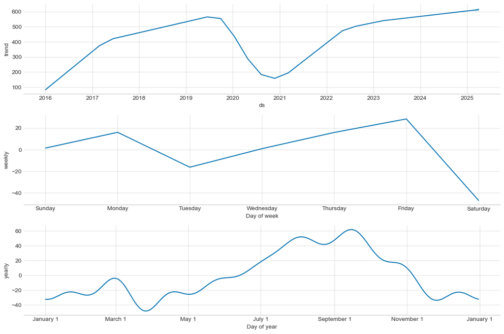

```
Letzte 5 Tage der Prophet Vorhersage:
```

|  | ds | yhat | yhat_lower | yhat_upper |
| --- | --- | --- | --- | --- |
| 3372 | 2025-03-26 | 566 | 461 | 667 |
| 3373 | 2025-03-27 | 582 | 475 | 688 |
| 3374 | 2025-03-28 | 594 | 491 | 702 |
| 3375 | 2025-03-29 | 520 | 419 | 626 |
| 3376 | 2025-03-30 | 569 | 468 | 665 |

```
2025-05-20 18:04:20,995 - INFO -
--- Prognose mit Linearer Regression (Test-Set Evaluation) ---
2025-05-20 18:04:20,998 - INFO - Lineare Regression: Training auf 3197 Tagen, Test auf 90 Tagen.
2025-05-20 18:04:21,001 - INFO - Lineare Regression - Evaluation auf Test-Set (90 Tage):
2025-05-20 18:04:21,002 - INFO -   RMSE: 101.30
2025-05-20 18:04:21,002 - INFO -   MAE:  66.72 (Durchschnittlicher absoluter Fehler pro Tag)
2025-05-20 18:04:21,002 - INFO -   Zum Vergleich: Durchschnittliche Flugzahl im Testset: 567.41
```

```
Beobachtung KAQ6 (Prophet, Zürich): Prophet-Modell für Zürich prognostiziert tendenziell steigende tägliche Flugzahlen für die nächsten ca. 90 Tage (basierend auf yhat Mitte Prognose vs. letzter Wert).
```

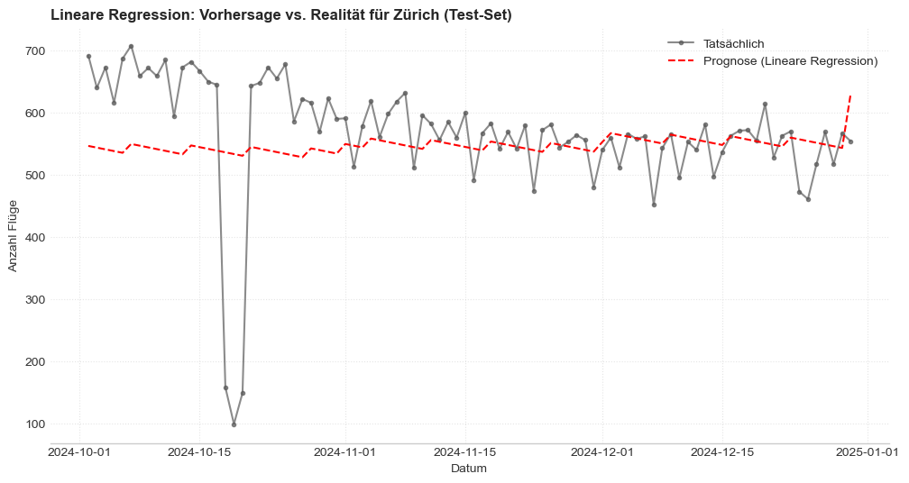

```
Beobachtung KAQ6 (LinReg, Zürich): Lineare Regression für Zürich zeigte einen MAE von 66.72 auf einem Test-Set von 90 Tagen.
```

```python
                except Exception as e_lr:
                    logging.error(f"Fehler bei der Linearen Regressions-Prognose für {PREDICTION_AIRPORT_NAME}: {e_lr}")
            else:
                print("Scikit-learn Bibliothek nicht verfügbar, überspringe Lineare Regressions-Prognose.")
else:
    logging.warning("Prädiktive Analyse (KAQ6): Datenanforderungen nicht erfüllt.")
    print("Prädiktive Analyse (KAQ6) übersprungen: Datenanforderungen nicht erfüllt.")
```

## 4. Schritt: Präsentation der Informationen (Present Information)

**Ziel:** Effektive Kommunikation der in Schritt 3 gewonnenen Beobachtungen, Kennzahlen und Prognosebeispiele (Marr, 2020).

Die Visualisierungen für KAQ 1-5 sind bereits in den jeweiligen Unterabschnitten von Schritt 3 integriert. Die Prognosevisualisierungen (KAQ 6) wurden in Abschnitt 3.7 erstellt.

### 4.1 Zusammenfassung der gesammelten Beobachtungen

Die Beobachtungen aus den vorangehenden Abschnitten wird hier nochmals zusammengefasst:

````python
if 'beobachtungen_dict' in locals() and beobachtungen_dict:
    print("--- Gesammelte Kernbeobachtungen aus der Analyse ---")
    for key, value in beobachtungen_dict.items():
        print(f"- {key.replace('_', ' ')}: {value}")
else:
    print("Keine Beobachtungen im 'beobachtungen_dict' gesammelt.")
# ```
````

```
--- Gesammelte Kernbeobachtungen aus der Analyse ---
- KAQ1 Verteilung: Zürich (LSZH) war der verkehrsreichste der analysierten Flughäfen mit 1,390,722 Flügen (47.3% des Volumens der analysierten Flughäfen).
- KAQ1 Trend LSZH: Am Zürich erreichte das Aufkommen 2024 mit 215,020 Flügen seinen Höhepunkt und 2016 mit 72,330 seinen Tiefpunkt im Analysezeitraum.
- KAQ2 Gesamt CH: Airline-Code 'SWR' war im analysierten Schweizer Luftraum am häufigsten mit 836,457 Flügen (28.9% aller Flüge mit identifizierbarem Airline-Code).
- KAQ2 LSZH: Am Flughafen Zürich war Airline-Code 'SWR' am häufigsten (714,104 Flüge, 51.8% der Flüge mit Airline-Code an diesem FH).
- KAQ3 Route 0: Für Zürich war EGLL (EGLL) mit 30,840 Flügen die häufigste Herkunft.
- KAQ3 Route 1: Von Zürich war EGLL (EGLL) mit 29,289 Flügen das häufigste Ziel.
- KAQ3 Route 2: Für Genève war EGLL (EGLL) mit 29,089 Flügen die häufigste Herkunft.
- KAQ3 Route 3: Von Genève war EGLL (EGLL) mit 30,370 Flügen das häufigste Ziel.
- KAQ4 Gesamt: Der Flugverkehr mit Schweizer Bezug war primär 'International' (ca. 91.4%), nationale Flüge machten ca. 6.5% aus.
- KAQ5 Stats All: Median der Netzwerksichtbarkeitsdauer (alle gültigen Flüge): 73.1 Min (Durchschnitt: 108.4 Min).
- KAQ5 Stats Filtered: Median der Netzwerksichtbarkeitsdauer (gefiltert 1min-20h): 73.1 Min (Durchschnitt: 106.3 Min).
- KAQ5 FH Vergleich: Die durchschnittliche Netzwerksichtbarkeitsdauer (gefiltert) variiert zwischen den Flughäfen, von 52.6 Min (Bern-Belp) bis 126.1 Min (Zürich).
- KAQ6 Prophet LSZH: Prophet-Modell für Zürich prognostiziert tendenziell steigende tägliche Flugzahlen für die nächsten ca. 90 Tage (basierend auf yhat Mitte Prognose vs. letzter Wert).
- KAQ6 LinReg LSZH: Lineare Regression für Zürich zeigte einen MAE von 66.72 auf einem Test-Set von 90 Tagen.
```

### 4.2 Visualisierung: Jährlicher Trend am Flughafen Zürich (KAQ 1)

Die Visualisierung für KAQ 1 wurden bereits in **Abschnitt 3.2** erzeugt und angezeigt. Die Darstellung zeigt die Entwicklung der Flugzahlen pro Jahr für den verkehrsreichsten Flughafen, inklusive prozentualer Vorjahresveränderung.

### 4.3 Visualisierung: Top Fluggesellschaften (Gesamt und Flughafen Zürich) (KAQ 2)

Diese Tabellen zur Visualisierung der Top Fluggesellschaften wurde bereits in **Abschnitt 3.3** integriert. Sie listen die aktivsten Airline-Codes im analysierten Schweizer Luftraum und spezifisch für den Flughafen Zürich auf.

### 4.4 Visualisierung: Top Routen pro Flughafen (KAQ 3)

Diese Tabellen wurden bereits in **Abschnitt 3.4** aufbereitet. Für jeden analysierten Flughafen werden die Top 10 Herkunfts- und Zielflughäfen (ICAO-Codes) mit der jeweiligen Anzahl an Flügen dargestellt.

### 4.5 Visualisierung: Fluglokalität (Gesamt und pro Flughafen) (KAQ 4)

Diese Tabellen wurden bereits in **Abschnitt 3.5** erzeugt und angezeigt. Es wird die Verteilung des Flugverkehrs auf nationale, internationale und andere Segmente gezeigt, sowohl gesamt für alle Schweizer Flüge als auch detailliert pro Flughafen.

### 4.6 Visualisierung: Netzwerksichtbarkeitsdauer (KAQ 5)

Deskriptive Statistiken (Tabellen) zur Netzwerksichtbarkeitsdauer wurden in **Abschnitt 3.6** dargestellt. Dies umfasst Statistiken für alle gültigen Flüge, für einen gefilterten, plausiblen Dauerbereich und einen Vergleich der Durchschnitts- und Mediandauer pro Flughafen.

### 4.7 Visualisierung: Prognose Flugaufkommen (Beispielhafter Flughafen) (KAQ 6)

Die Diagramme zur Prognose des täglichen Flugaufkommens mittels Prophet (Vorhersageplot und Komponentenplot) sowie der Vergleich der Linearen Regression mit tatsächlichen Werten auf einem Test-Set wurden in **Abschnitt 3.7** erzeugt und angezeigt.

## 5. Schritt: Datengestützte Entscheidungen und Empfehlungen (Make Data-Driven Decisions)

**Ziel:** Das Ziel dieses Schrittes ist di Überführung der gewonnenen Informationen in Insights und potenzielle Handlungsempfehlungen (Marr, 2020).

### 5.2 Potenzielle Implikationen und Entscheidungsfelder für Stakeholder

Basierend auf diesen Insights ergeben sich folgende potenzielle Überlegungen:

- **Für Flughafenbetreiber:**
  - **Strategische Kapazitätsplanung:** Langfristige Trends (KAQ1) und Prognosen (KAQ6) sollten als Basis für Investitionsentscheidungen in Infrastruktur dienen.
  - **Operative Ressourcenplanung:** Prognosen (KAQ6) und saisonale Muster (aus Prophet) können helfen, Personal und Gates effizienter zu planen.
- **Für Fluggesellschaften:**
  - **Netzwerk- und Flottenplanung:** Analyse historischer Routenperformance (KAQ3) und Nachfrageprognosen (KAQ6) können Entscheidungen über Frequenzen, Kapazitäten und neue Routen unterstützen.
- **Für Flugsicherung/Regulierung:**
  - **Luftraummanagement:** Langfristige Verkehrsentwicklung (KAQ1, KAQ6) und Daten zur Flugdauer (KAQ5) können bei der Planung von Luftraumkapazitäten und Effizienzsteigerungen helfen.

**Wichtiger Hinweis:** Diese Implikationen sind basierend auf einer ersten Analyse im Rahmen dieser Arbeit. Entgültige Entscheidungen benötigen zusätzliche Daten und Expertenwissen.

### 5.3 Limitationen der Analyse und Feedback Loop / Nächste Schritte

Die folgenden Limitationen sollten bei der Interpretation der Resultate berücksichtigt werden:

- **Datenqualität**: Im Kapitel 2.2 wurden bereits die Mängel zur Datenqualität aufgezeigt.
- **Modellvereinfachungen:** Die Prognosemodelle sind grundlegend und berücksichtigen keine externen Schocks oder detaillierte ökonomische Variablen. Dadurch ist die Genauigkeit begrenzt.

**Feedback Loop / Nächste Schritte für verbesserte Entscheidungsfindung:**

1. **Verfeinerung der Prognosemodelle:** Einbeziehung externer Variablen (z.B. BIP, Ölpreis, spezielle Events, Pandemie-Indikatoren), Hyperparameter-Optimierung, Vergleich mit weiteren Modellen (z.B. ARIMA, LSTM), robustere Validierungsstrategien (z.B. rollierende Kreuzvalidierung).
2. **Kausalanalyse:** Untersuchung der Ursachen für beobachtete Trendbrüche oder starke Schwankungen (z.B. detaillierter Einfluss von COVID-19, Wirtschaftskrisen, Airline-Pleiten).
3. **Szenarioanalyse:** Entwicklung von Prognosen unter verschiedenen Annahmen (z.B. optimistisches, pessimistisches, Basis-Szenario für externe Faktoren). (Weitere Punkte wie Datenanreicherung, detailliertere Segmentierung, Validierung der Approximationen, qualitative Ergänzung aus der vorherigen Version bleiben relevant.)

## 6. Literaturverzeichnis

- Marr, B. (2020). *From data to decisions: A five-step approach to data-driven decision-making*. CPA Canada. https://www.cpacanada.ca/MAGs
- OpenSky Network. (o. J.). *Trino – SQL-based access to the OpenSky historical database*. Abgerufen am 2. Mai 2025, von https://opensky-network.org/data/trino
- swissinfo.ch. (2024, Februar 14). *Passagierzahlen an Schweizer Flughäfen steigen*. Abgerufen am 10. Mai 2025, von https://www.swissinfo.ch/ger/passagierzahlen-an-schweizer-flugh%C3%A4fen-steigen/72926380

## 7. Verwendete Hilfsmittel

Neben dem Literaturverzeichnis und den Unteralgen im Unterricht, kamen für die Erstellung dieser Arbeit folgende Hilfsmittel zum Einsatz:

- **PyCharm** sowie **Google Colab** zur Entwicklung, Ausführung und Validierung des Codes.
- **GitHub Copilot** als KI-gestützter Programmierassistent zur Code-Vervollständigung und Syntaxunterstützung in PyCharm.
- **ChatGPT** zur sprachlichen Überprüfung (Rechtschreibung, Stil, Einheitlichkeit) sowie zur Verbesserung von Code-Abschnitten.

## 8. Anhang

### 8.1 Daten-Glossar / Metadaten

- **icao24:** Eindeutiger 24-bit Transpondercode des Flugzeugs.
- **firstseen:** Zeitstempel der ersten Sichtung im Netzwerk (UTC).
- **lastseen:** Zeitstempel der letzten Sichtung im Netzwerk (UTC).
- **query_airport:** ICAO-Code des Flughafens, für den die Daten primär abgefragt wurden.
- **flight_type:** 'ARRIVAL' oder 'DEPARTURE' bezogen auf den `query_airport`.
- **callsign:** Rufzeichen des Fluges.
- **departure_airport:** ICAO-Code des Abflughafens (wenn bekannt).
- **arrival_airport:** ICAO-Code des Zielflughafens (wenn bekannt).
- **network_duration_minutes:** Berechnete Dauer zwischen firstseen und lastseen in Minuten (Approximation).
- **airline_code:** Aus den ersten 3 Buchstaben des Callsigns extrahierter Code (Approximation).
- **locality:** Berechnete Kategorie (National, International, etc.).
- **jahr:** Jahr des `firstseen` Zeitstempels.
- **monat_nr:** Monat (numerisch, 1-12) des `firstseen` Zeitstempels.
- **monat_name:** Monatsname des `firstseen` Zeitstempels.
- **wochentag_nr:** Wochentag (numerisch, 0=Montag bis 6=Sonntag) des `firstseen` Zeitstempels.
- **wochentag_name:** Name des Wochentags des `firstseen` Zeitstempels.

**Mapping ICAO zu Flughafenname:**

```python
FLUGHAFEN_MAP = {
    'LSZH': 'Zürich', 'LSGG': 'Genève', 'LSZB': 'Bern-Belp',
    'LSZA': 'Lugano-Agno', 'LSZR': 'St. Gallen-Altenrhein',
    'LFSB': 'Basel-Mulhouse (EuroAirport)'
}
print(FLUGHAFEN_MAP)
```

```
{'LSZH': 'Zürich', 'LSGG': 'Genève', 'LSZB': 'Bern-Belp', 'LSZA': 'Lugano-Agno', 'LSZR': 'St. Gallen-Altenrhein', 'LFSB': 'Basel-Mulhouse (EuroAirport)'}
```

### 8.2 Detailierte Datenübersichten

**Bereinigte Daten Übersicht (`df_cleaned.info()`):**

```python
df_cleaned.info()
```

```
<class 'pandas.core.frame.DataFrame'>
Index: 2941079 entries, 0 to 2941853
Data columns (total 11 columns):
 #   Column                    Dtype
---  ------                    -----
 0   icao24                    object
 1   firstseen                 datetime64[ns, UTC]
 2   departure_airport         object
 3   lastseen                  datetime64[ns, UTC]
 4   arrival_airport           object
 5   callsign                  object
 6   query_airport             object
 7   flight_type               object
 8   network_duration_minutes  float64
 9   airline_code              object
 10  locality                  object
dtypes: datetime64[ns, UTC](2), float64(1), object(8)
memory usage: 269.3+ MB
```

**Bereinigte Daten Deskriptive Statistik (`df_cleaned.describe(include=np.number)`):**

```python
display(bereinigt_describe)
```

|  | network_duration_minutes |
| --- | --- |
| count | 2.941079e+06 |
| mean | 1.083882e+02 |
| std | 1.290952e+02 |
| min | 1.001667e+01 |
| 25% | 5.298333e+01 |
| 50% | 7.313333e+01 |
| 75% | 1.070833e+02 |
| max | 2.532517e+03 |

**Finale Daten Übersicht (`df_final.info()`):**

```python
df_final.info()
```

```
<class 'pandas.core.frame.DataFrame'>
Index: 2941079 entries, 0 to 2941853
Data columns (total 18 columns):
 #   Column                    Dtype
---  ------                    -----
 0   icao24                    object
 1   firstseen                 datetime64[ns, UTC]
 2   departure_airport         object
 3   lastseen                  datetime64[ns, UTC]
 4   arrival_airport           object
 5   callsign                  object
 6   query_airport             object
 7   flight_type               object
 8   network_duration_minutes  float64
 9   airline_code              object
 10  locality                  object
 11  jahr                      Int64
 12  monat_nr                  Int64
 13  monat_name                object
 14  wochentag_nr              Int64
 15  wochentag_name            object
 16  stunde                    Int64
 17  quartal                   Int64
dtypes: Int64(5), datetime64[ns, UTC](2), float64(1), object(10)
memory usage: 440.4+ MB
```

**Finale Daten Deskriptive Statistik (`df_final.describe(include='all')`):**

```python
display(df_final.describe(include='all'))
```

|  | icao24 | firstseen | departure_airport | lastseen | arrival_airport | callsign | query_airport | flight_type | network_duration_minutes | airline_code | locality | jahr | monat_nr | monat_name | wochentag_nr | wochentag_name | stunde | quartal |
| --- | --- | --- | --- | --- | --- | --- | --- | --- | --- | --- | --- | --- | --- | --- | --- | --- | --- | --- |
| count | 2941079 | 2941079 | 2877372 | 2941079 | 2941079 | 2941079 | 2941079 | 2941079 | 2.941079e+06 | 2895958 | 2941079 | 2941079.0 | 2941079.0 | 2941079 | 2941079.0 | 2941079 | 2941079.0 | 2941079.0 |
| unique | 21702 | NaN | 1904 | NaN | 2598 | 102743 | 6 | 2 | NaN | 2374 | 3 | <NA> | <NA> | 12 | <NA> | 7 | <NA> | <NA> |
| top | 4B17DF | NaN | LSZH | NaN | LSZH | nan | LSZH | ARRIVAL | NaN | SWR | International | <NA> | <NA> | August | <NA> | Friday | <NA> | <NA> |
| freq | 12320 | NaN | 741420 | NaN | 725347 | 7036 | 1390722 | 1484409 | NaN | 836457 | 2687554 | <NA> | <NA> | 274649 | <NA> | 456257 | <NA> | <NA> |
| mean | NaN | 2021-01-04 23:26:48.947889664+00:00 | NaN | 2021-01-05 01:15:12.240294656+00:00 | NaN | NaN | NaN | NaN | 1.083882e+02 | NaN | NaN | 2020.50352 | 6.624332 | NaN | 2.997633 | NaN | 11.989726 | 2.540104 |
| min | NaN | 2016-01-01 05:29:27+00:00 | NaN | 2016-01-01 06:50:59+00:00 | NaN | NaN | NaN | NaN | 1.001667e+01 | NaN | NaN | 2016.0 | 1.0 | NaN | 0.0 | NaN | 0.0 | 1.0 |
| 25% | NaN | 2018-09-26 14:02:01.500000+00:00 | NaN | 2018-09-26 15:53:39+00:00 | NaN | NaN | NaN | NaN | 5.298333e+01 | NaN | NaN | 2018.0 | 4.0 | NaN | 1.0 | NaN | 8.0 | 2.0 |
| 50% | NaN | 2021-04-19 21:06:37+00:00 | NaN | 2021-04-20 03:05:56+00:00 | NaN | NaN | NaN | NaN | 7.313333e+01 | NaN | NaN | 2021.0 | 7.0 | NaN | 3.0 | NaN | 12.0 | 3.0 |
| 75% | NaN | 2023-05-16 09:29:35.500000+00:00 | NaN | 2023-05-16 11:34:30.500000+00:00 | NaN | NaN | NaN | NaN | 1.070833e+02 | NaN | NaN | 2023.0 | 9.0 | NaN | 5.0 | NaN | 16.0 | 3.0 |
| max | NaN | 2024-12-30 22:05:17+00:00 | NaN | 2024-12-30 22:59:52+00:00 | NaN | NaN | NaN | NaN | 2.532517e+03 | NaN | NaN | 2024.0 | 12.0 | NaN | 6.0 | NaN | 23.0 | 4.0 |
| std | NaN | NaN | NaN | NaN | NaN | NaN | NaN | NaN | 1.290952e+02 | NaN | NaN | 2.556095 | 3.383258 | NaN | 1.998695 | NaN | 4.8431 | 1.101904 |

## Ende des Notebooks

%%